# Pre-process TSCA2019 MEA Acute data

August 4, 2023

# Set up

## Load libraries

```r
rm(list = ls())
library(data.table)
library(openxlsx)
```

```r
library(stringi)
library(ggplot2)
```

## Project variables definitions

```r
# Note that paths can be written relative to the .Rproj

project_name <- "TSCA2019" # e.g. "name2020"

spidmap_file <- "L:/Lab/NHEERL_MEA/Project TSCA 2019/EPA_25092_EPA-Shafer_339_20190722.xlsx"
spid_sheet <- 1 # sheet name or number in spidmap_file

project.input.dir <- "L:/Lab/NHEERL_MEA/Project TSCA 2019/Acute TSCA Conc Response"
scripts.dir <- "mea-acute-neural-stats-to-mc0-scripts"
assay_component_map_filename <- "neural_stats_acsn_to_tcpl_acnm_map.xlsx"

project.output.dir <- file.path(project_name) # where the "output" folder should be created

select.neural.stats.files <- F # select new neural stats files, or use the files in the most recent neural_stats_files_log?
select.calculations.files <- F # select new calculations files, or use the files in the most recent calculations_files_log?
select.raw.cytotox.files <- F # select new raw cytotoxicity files, or use the files in the most recent raw_cytotox_files_log?
```

Set up folders, source functions, and load ascn-acnm map

```r
if (!dir.exists(file.path(project_name))) dir.create(file.path(project_name))
if (!dir.exists(file.path(project_name,"output"))) dir.create(file.path(project_name,"output"))

# source all functions in folder 'mea-acute-neural-stats-to-mc0-scripts'
scripts <- list.files(path = scripts.dir, pattern = "\\.R$", full.names = T, recursive = F)
scripts <- Filter(function(x) !grepl('deprecated',x), scripts)
for (scripti in scripts)
  source(scripti)

# loading acsn_acnm map
acsn_map <- as.data.table(read.xlsx(assay_component_map_filename))
rm(assay_component_map_filename)
```

Save items to be kept throughout all steps

```r
keep.items <- c(ls(),'keep.items')
```

# Step 0

## Read any .txt files with important notes

Scan for txt files with notes that might affect dosing, wllq

```r
txt.files <- list.files(project.input.dir, pattern = '\\.txt', recursive = T, full.names = T)
```

View any README .txt files

```r
# Read in the READMEs
readmes <- txt.files[grepl('read( )*me',tolower(txt.files))]
if (length(readmes) > 0) {
  for (i in 1:length(readmes)) {
    cat(i,'\n')
    cat(dirname(readmes[i]),'\n')
    cat(scan(readmes[i], what = character(), sep = '\n', quiet = T), sep = '\n')
    cat('\n')
  }
} else {
  cat('no readme.txt files')
}
```

```
## 1
## L:/Lab/NHEERL_MEA/Project TSCA 2019/Acute TSCA Conc Response/20210526 Culture G26 (201B07, 201C02, 201C03 may need repeat)
## Plate 1 CellTiter Blue blank control is not valid
## blank values are taken from plate 2 blank controls
```

```r
# 1
# L:/Lab/NHEERL_MEA/Project TSCA 2019/Acute TSCA Conc Response/20210526 Culture G26 (201B07, 201C02, 201C03 may need repeat)
# Plate 1 CellTiter Blue blank control is not valid
# blank values are taken from plate 2 blank controls
```

5/11/23: Seline has already updated the formula in the Calculations file such that the corrected optical density values for plate 1 are corrected to the blanks from plate 2. No further updates needed.

(If there was an important well quality note, enter it in one of the well_quality_table’s, to be merged later on)

Check for any other .txt files that look relevant

```r
cat(setdiff(txt.files,readmes), sep = "\n")
```

```
## L:/Lab/NHEERL_MEA/Project TSCA 2019/Acute TSCA Conc Response/20201104 Culture G1/update_log.txt
## L:/Lab/NHEERL_MEA/Project TSCA 2019/Acute TSCA Conc Response/20210120 Culture G6 (198F11 may need repeat)/update_log.txt
## L:/Lab/NHEERL_MEA/Project TSCA 2019/Acute TSCA Conc Response/20210120 Culture G7/update_log.txt
## L:/Lab/NHEERL_MEA/Project TSCA 2019/Acute TSCA Conc Response/20210224 Culture G10/update_log.txt
## L:/Lab/NHEERL_MEA/Project TSCA 2019/Acute TSCA Conc Response/20210224 Culture G11/update_log.txt
## L:/Lab/NHEERL_MEA/Project TSCA 2019/Acute TSCA Conc Response/20210310 Culture G12 (all but 199B10 need repeat)/update_log.txt
## L:/Lab/NHEERL_MEA/Project TSCA 2019/Acute TSCA Conc Response/20210428 Culture G20/update_log.txt
## L:/Lab/NHEERL_MEA/Project TSCA 2019/Acute TSCA Conc Response/20210609 Culture G30 (Repeat all)/update_log.txt
```

```r
# (if there are any other txt files that look like they might have relevant notes, review the contents of those files as well)
```

Update logs are just files I made to note updates to the Calculations files - these are fine.

## Get list culture folders to review

Get a list of all cultures in the main folder to check off as I review wllq notes in lab notebook and determine usability.

`eval = FALSE` because I only need to run this once, then will manually add notes.

```r
# Just want to get a list of all cultures in the main folder
group.folders <- list.files(path = project.input.dir, pattern = '[0-9]{8}', include.dirs = T)
cat(group.folders, sep ='\n')
wb <- createWorkbook()
addWorksheet(wb, 'TSCA cultures')
writeData(wb, 1, data.table('culture_folders' = group.folders))
saveWorkbook(wb, file = 'TSCA2019/tables/TSCA2019_culture_folders_to_review.xlsx')
```

## Get list of neural stats files, meta data files, and (opt) raw cytotoxicity data files

```r
# For each culture, get all files under "Neural Statistic Compiler" folder
# if there are not exactly 6 files per folder -> flag (including if there are 0)
group.folders <- list.files(path = project.input.dir,
                            pattern = '[0-9]{8}',
                            include.dirs = T,
                            full.names = T)
print(basename(group.folders))
```

```
##  [1] "20201104 Culture G1"
##  [2] "20201125 Culture G2"
##  [3] "20201125 Culture G3"
##  [4] "20201202 Culture G4"
##  [5] "20201202 Culture G5"
##  [6] "20210120 Culture G6 (198F11 may need repeat)"
##  [7] "20210120 Culture G7"
##  [8] "20210210 Culture G8"
##  [9] "20210210 Culture G9(may need repeat)"
## [10] "20210224 Culture G10"
## [11] "20210224 Culture G11"
## [12] "20210310 Culture G12 (all but 199B10 need repeat)"
## [13] "20210310 Culture G13"
## [14] "20210324 Culture G14 (199E02 may need repeat)"
## [15] "20210324 Culture G15 (199E08, 199E09, 199E10 may need repeat)"
```

[output cut: 22 more lines]

(edit the list of group folders to include if necessary)

Looks okay!

Select input files to use, store files in .txt file

```r
if (select.neural.stats.files) {

  # Use below lines of code to get all files in folder "Neural Statistic Compiler" for each group
  # Or, if project is not cleanly organized, create your own method to identify the neural statistics compiler files to be read

  # Get all neural stats files in folder
  neural.stats.files <- sapply(group.folders,
                               function(folderi) list.files(path = file.path(folderi,
                                                                             'Neural Statistic Compiler'),
                                                            pattern = '\\.csv',
                                                            full.names = T,
                                                            recursive = T))

  # Check that there are exactly 6 neural stats files per group
  # (1 baseline and 1 treated X 3 plates)
  num.files.per.group <- lapply(neural.stats.files, length)
  cat('Groups that did not match exactly 6 neural stats files:')
  num.files.per.group[num.files.per.group != 6]

  # (edit the list of neural.stats.files if needed)

  # Exclude 20201125_MW71-7113 (because treated recording broken up), for now (will investigate Seline's methods to combine and if I agree if time later)
  # Similar situation for G24, plate 75-8213
  neural.stats.files <- sapply(neural.stats.files,
                               function(files) files[!grepl('20201125_MW71-7113',files)])
  neural.stats.files <- sapply(neural.stats.files,
                               function(files) files[!grepl('20210512_MW75-8213',files)])
  num.files.per.group <- lapply(neural.stats.files, length)

  # Final check:
  # stopifnot(sum(num.files.per.group != 6) == 0)
  # (removing this check because there are 2 groups with 1 plate removed)
  # (so I'll just confirm that there are an even # of files per group)
  stopifnot(sum(unlist(num.files.per.group) %% 2) == 0)

  # Write files to log
  writeFilesLog(unlist(neural.stats.files), project_name, files_type = 'neural_stats')

}
```

Select calculations files

```r
if (select.calculations.files) {

  # Use below lines of code to get files in group folders that contain the phrase "Calculations"
  # Or, if project is not cleanly organized, create your own method to identify the Calculations files to be read

  # Get all calculations files in folder
  calc.files <- sapply(group.folders,
                       function(folderi) list.files(path = file.path(folderi),
                                                    pattern = 'Calculations',
                                                    full.names = T,
                                                    recursive = F))

  # Remove any dummy "ghost" files
  calc.files <- sapply(calc.files,
                       function(files) files[!grepl('\\~\\$',basename(files))])

  # Check that there is exactly 1 calc file per group
  num.files.per.group <- lapply(calc.files, length)
  cat('Groups that did not match exactly 1 Calculations file:')
  num.files.per.group[num.files.per.group != 1]

  # (edit the list of calc.files if needed)

  # Final check:
  stopifnot(sum(num.files.per.group != 1) == 0)

  # Write files to log
  writeFilesLog(unlist(calc.files), project_name, files_type = 'calculations')

}
```

Select raw cytotoxicity data files

```r
if (select.raw.cytotox.files) {

  # Use below lines of code to get files in group folders that contain the raw cytotoxity data
  # Or, if project is not cleanly organized, create your own method to identify the files to be read

  # Get all cytotox files
  # (note that names are not retained with recursive = T)
  all.xls.files <- unlist(lapply(group.folders,
                                 function(folderi) list.files(path = file.path(folderi),
                                                              pattern = '\\.xls$',
                                                              full.names = T,
                                                              recursive = T)))
  raw.cytotox.files.ungrouped <- all.xls.files[grepl('Cytotoxicity',all.xls.files)]
  all.group.folders <- dirname(dirname(raw.cytotox.files.ungrouped))
  raw.cytotox.files <- split(raw.cytotox.files.ungrouped, f = all.group.folders)

  # Check that there is exactly 1 LDH file per group
  num.LDH.per.group <- sapply(raw.cytotox.files, function(seti) sum(grepl('LDH',seti)))
  cat('Groups that do not have exactly 1 LDH file:')
  num.LDH.per.group[num.LDH.per.group != 1]

  # (if any, edit selection or rename files if missing "LDH" in name)

  # Check that there are exactly 3 AB files per group
  num.AB.per.group <- sapply(raw.cytotox.files, function(seti) sum(!grepl('LDH',unlist(seti))))
  cat('Groups that do not have exactly 3 AB file:')
  num.AB.per.group[num.AB.per.group != 3]

  # Write files to log
  writeFilesLog(unlist(raw.cytotox.files), project_name, files_type = 'raw_cytotox')

}
```

# Step 1

## Read neural stats files

Extract all of the data from the files and transform into long data format

```r
dat.neural.stats <- extractAllData(project_name,
                                   acsn_map,
                                   append = F,
                                   noisy_functions = FALSE)
```

```
##
##
## Level 1 - Extract All Data:
##
## Reading from TSCA2019_neural_stats_files_log.txt...
## Got 218 files.
## Reading data from files...
## ... 50 complete
## ... 100 complete
## ... 150 complete
## ... 200 complete
```

```
## Done!
```

Get plate.id from filename for files that don’t have plate ID in file header (because were ran with older machine/software)

```r
dat.neural.stats[is.na(plate.id), .N, by = .(neural_stats_file, plate.id)]
```

| neural_stats_file | plate.id | N |
| --- | --- | --- |
| AC_20210811_MW75-9119_13(000)_Neural Statistics Compiler(000).csv | NA | 2064 |
| AC_20210811_MW75-9119_13(001)_Neural Statistics Compiler(000).csv | NA | 2064 |
| AC_20210811_MW75-9120_13(000)_Neural Statistics Compiler(000).csv | NA | 2064 |
| AC_20210811_MW75-9120_13(001)_Neural Statistics Compiler(000).csv | NA | 2064 |
| AC_20210811_MW75-9201_13(000)_Neural Statistics Compiler(000).csv | NA | 2064 |
| AC_20210811_MW75-9201_13(001)_Neural Statistics Compiler(000).csv | NA | 2064 |

```r
dat.neural.stats[, check_plate_ids := is.na(plate.id)]
dat.neural.stats[, .N, by =.(setting_axis.version, plate_id_is_NA = is.na(plate.id))] # all the plates that dont' have plate ids come from the same axis version
```

| setting_axis.version | plate_id_is_NA | N |
| --- | --- | --- |
| 1.5.2.4 | FALSE | 119712 |
| 2.0.4.21 | FALSE | 312576 |
| 2.3.3.5 | TRUE | 12384 |
| 3.2.3.1 | FALSE | 12672 |

```r
# Attempt to extract plate.id from the file name
dat.neural.stats[is.na(plate.id), plate.id := stri_extract(neural_stats_file, regex = 'MW[^_]+')]

# Check result
dat.neural.stats[check_plate_ids == TRUE, .N, by = .(plate.id, neural_stats_file)]
```

| plate.id | neural_stats_file | N |
| --- | --- | --- |
| MW75-9119 | AC_20210811_MW75-9119_13(000)_Neural Statistics Compiler(000).csv | 2064 |
| MW75-9119 | AC_20210811_MW75-9119_13(001)_Neural Statistics Compiler(000).csv | 2064 |
| MW75-9120 | AC_20210811_MW75-9120_13(000)_Neural Statistics Compiler(000).csv | 2064 |
| MW75-9120 | AC_20210811_MW75-9120_13(001)_Neural Statistics Compiler(000).csv | 2064 |
| MW75-9201 | AC_20210811_MW75-9201_13(000)_Neural Statistics Compiler(000).csv | 2064 |
| MW75-9201 | AC_20210811_MW75-9201_13(001)_Neural Statistics Compiler(000).csv | 2064 |

Looks good!

## Determine run type for each file

Get a numeric, sortable version of the time from the original_start_time and experiment start time (to use to help determine which files are baseline versus treated).

```r
dat.neural.stats <- getNumericTimeValFromString(dat.neural.stats, time_string = 'original_file_time', new_cols_suffix = 'oft')
```

```
## The following columns have been added to dat.neural.stats:
##  time_includes_sec_oft, meridiem_given_oft, time_char_oft, hour_oft, time_format_oft, time_posix_num_oft
```

```r
dat.neural.stats <- getNumericTimeValFromString(dat.neural.stats, time_string = 'experiment_start_time', new_cols_suffix = 'est')
```

```
## The following columns have been added to dat.neural.stats:
##  time_includes_sec_est, meridiem_given_est, time_char_est, hour_est, time_format_est, time_posix_num_est
```

Rank the files associated with each experiment.date - plate.id combination based on the experiment start time, original file time, and neural_stats_file (name). Ideally, each experiment.date - plate.id combination will correspond to 2 files, with 1 file clearly corresponding to the chronologically first “baseline” recording and the other the secondary “treated” recording. Ideally this ranking would be agree for all 3 methods. If the rankings do not appear for a pair of files associated with the same experiment.date + plate.id, manually determine which correspond to the treated vs baseline recordings.

Possible issues that might lead to difficulties in identifying the run type:

- abnormalities in file naming
- If the original file time or Experiment start time is in non-military time and the time, and the baseline recording is at 12:00 (PM, but not shown) and the treated recording is at 1:00 (PM, but not show), then the baseline vs treated recordings would not get sorted correctly.

The hope is that at least 1 of these 3 methods will work to identify the correct run_type.

Also note that the Neural Stats Compiler clock is offline so the actual time may not reflect reality (but it should still be internally consistent from the baseline to treated recording).

```r
# Determine the run type based on the 'original file time' and the 'experiment stat time' given in the neural statistics compiler file header
# rank = 1 -> baseline
# rank = 2 -> treated
dat.neural.stats[, file_rank_oft := frank(time_posix_num_oft, ties.method = 'dense'),
                 by = .(experiment.date, plate.id)]
dat.neural.stats[, file_rank_est := frank(time_posix_num_est, ties.method = 'dense'),
                 by = .(experiment.date, plate.id)]

# Determine the run type based on alpha-numeric sorting of the file names
dat.neural.stats[, file_rank_name := frank(neural_stats_file, ties.method = 'dense'),
                 by = .(experiment.date, plate.id)]
```

Check for discrepancies in file rank from the 3 methods

```r
dat.neural.stats[, .N, by = .(file_rank_oft, file_rank_name, file_rank_est)]
```

| file_rank_oft | file_rank_name | file_rank_est | N |
| --- | --- | --- | --- |
| 1 | 1 | 1 | 228672 |
| 2 | 2 | 2 | 222480 |
| 2 | 2 | 1 | 6192 |

```r
#   file_rank_est file_rank_oft file_rank_name      N
# 1:             1             1              1 228672
# 2:             2             2              2 222480
# 3:             1             2              2   6192

if (nrow(dat.neural.stats[!(file_rank_est == file_rank_oft & file_rank_oft == file_rank_name)]) != 0) {
  warning('Rankings of files for each experiment date and plate.id pair by experiment start time, original file time, and file name do not all agree')
}
```

Investigate cases where the rankings do not agree based on all of these methods.

```r
dat.neural.stats[file_rank_est != file_rank_oft, .N, by = .(experiment.date, plate.id, experiment_start_time, original_file_time)]
```

| experiment.date | plate.id | experiment_start_time | original_file_time | N |
| --- | --- | --- | --- | --- |
| 20201208 | MW71-7111 | 12/08/2020 10:32:25 | 12/08/2020 12:04:05 | 2064 |
| 20201208 | MW71-7112 | 12/08/2020 12:45:12 | 12/08/2020 14:10:03 | 2064 |
| 20210202 | MW72-8209 | 02/02/2021 12:46:36 | 02/02/2021 14:18:38 | 2064 |

```r
#    experiment.date  plate.id experiment_start_time  original_file_time    N
# 1:        20201208 MW71-7111   12/08/2020 10:32:25 12/08/2020 12:04:05 2064
# 2:        20201208 MW71-7112   12/08/2020 12:45:12 12/08/2020 14:10:03 2064
# 3:        20210202 MW72-8209   02/02/2021 12:46:36 02/02/2021 14:18:38 2064
dat.neural.stats[, date_plate := paste0(experiment.date, '_',plate.id)]
check.dps <- dat.neural.stats[file_rank_est != file_rank_oft, unique(date_plate)]
dat.neural.stats[date_plate %in% check.dps, .N, by = .(neural_stats_file, file_rank_est, file_rank_oft, experiment_start_time, original_file_time)]
```

| neural_stats_file | file_rank_est | file_rank_oft | experiment_start_time | original_file_time | N |
| --- | --- | --- | --- | --- | --- |
| AC_20201125_MW71-7111_13_00(001)(000).csv | 1 | 1 | 12/08/2020 10:32:25 | 12/08/2020 10:52:26 | 2064 |
| AC_20201125_MW71-7111_13_00(002)(000).csv | 1 | 2 | 12/08/2020 10:32:25 | 12/08/2020 12:04:05 | 2064 |
| AC_20201125_MW71-7112_13_00(000)(000).csv | 1 | 1 | 12/08/2020 12:45:12 | 12/08/2020 13:05:13 | 2064 |
| AC_20201125_MW71-7112_13_00(001)(000).csv | 1 | 2 | 12/08/2020 12:45:12 | 12/08/2020 14:10:03 | 2064 |
| AC_20210120_MW72-8209_13_00(000)(000).csv | 1 | 1 | 02/02/2021 12:46:36 | 02/02/2021 13:08:34 | 2064 |
| AC_20210120_MW72-8209_13_00(001)(000).csv | 1 | 2 | 02/02/2021 12:46:36 | 02/02/2021 14:18:38 | 2064 |

```r
#                            neural_stats_file file_rank_est file_rank_oft experiment_start_time  original_file_time    N
# 1: AC_20201125_MW71-7111_13_00(001)(000).csv             1             1   12/08/2020 10:32:25 12/08/2020 10:52:26 2064
# 2: AC_20201125_MW71-7111_13_00(002)(000).csv             1             2   12/08/2020 10:32:25 12/08/2020 12:04:05 2064
# 3: AC_20201125_MW71-7112_13_00(000)(000).csv             1             1   12/08/2020 12:45:12 12/08/2020 13:05:13 2064
# 4: AC_20201125_MW71-7112_13_00(001)(000).csv             1             2   12/08/2020 12:45:12 12/08/2020 14:10:03 2064
# 5: AC_20210120_MW72-8209_13_00(000)(000).csv             1             1   02/02/2021 12:46:36 02/02/2021 13:08:34 2064
# 6: AC_20210120_MW72-8209_13_00(001)(000).csv             1             2   02/02/2021 12:46:36 02/02/2021 14:18:38 2064
```

Okay, so we have 3 plates where the experiment start time is the same in both the treated and recording files. I could probably just take the original file time and use that, especially since it agrees with the file_rank_name.

Usually, the original file time is about 20 minutes after the experiment start time.

```r
dat.neural.stats[, .N, by = .(experiment.date, plate.id, experiment_start_time, original_file_time, file_rank_name)][order(experiment.date, plate.id)]
```

| experiment.date | plate.id | experiment_start_time | original_file_time | file_rank_name | N |
| --- | --- | --- | --- | --- | --- |
| 20201117 | MW71-7104 | 11/17/2020 10:26 | 11/17/2020 10:52 | 1 | 2064 |
| 20201117 | MW71-7104 | 11/17/2020 11:37:54 | 11/17/2020 11:57:55 | 2 | 2064 |
| 20201117 | MW71-7105 | 11/17/2020 13:02:17 | 11/17/2020 13:02:17 | 1 | 2064 |
| 20201117 | MW71-7105 | 11/17/2020 13:47:37 | 11/17/2020 14:07:39 | 2 | 2064 |
| 20201117 | MW71-7106 | 11/17/2020 14:48:51 | 11/17/2020 15:11:41 | 1 | 2064 |
| 20201117 | MW71-7106 | 11/17/2020 15:57:59 | 11/17/2020 16:18:00 | 2 | 2064 |
| 20201208 | MW71-7111 | 12/08/2020 10:32:25 | 12/08/2020 10:52:26 | 1 | 2064 |
| 20201208 | MW71-7111 | 12/08/2020 10:32:25 | 12/08/2020 12:04:05 | 2 | 2064 |
| 20201208 | MW71-7112 | 12/08/2020 12:45:12 | 12/08/2020 13:05:13 | 1 | 2064 |
| 20201208 | MW71-7112 | 12/08/2020 12:45:12 | 12/08/2020 14:10:03 | 2 | 2064 |

[output cut: 208 more lines]

Most likely, the experiment start time corresponds to when the plate was put in the machine for the baseline recording or when the plate was dosed for the treated (so perhaps the experiment start time resets every time with lid is opened? Then the original file time would correspond to when the recording actually starts.

So it appears that for these 3 plates (MW71-7111, MW71-7112, and MW72-8209), the experiment start time did not reset after the dosing (perhaps these plates were ran on a different machine that didn’t require opening the lid?)

```r
dat.neural.stats[, .N, by = .(setting_axis.version, ranks_agree = file_rank_est == file_rank_oft)]
```

| setting_axis.version | ranks_agree | N |
| --- | --- | --- |
| 1.5.2.4 | TRUE | 113520 |
| 1.5.2.4 | FALSE | 6192 |
| 2.0.4.21 | TRUE | 312576 |
| 2.3.3.5 | TRUE | 12384 |
| 3.2.3.1 | TRUE | 12672 |

Well, there isn’t an axis version that explains this.

Regardless, I think we can rely on the ranking of the original file time and the file names to identify the treated and baseline recordings for these 3 plates.

Make final run_type determinations

```r
# Determine the file type - here I'm going to use the consensus of the file_rank_oft and the file_rank_name
dat.neural.stats[file_rank_oft == 1 & file_rank_name == 1, run_type := 'baseline']
dat.neural.stats[file_rank_oft == 2 & file_rank_name == 2, run_type := 'treated']
stopifnot(nrow(dat.neural.stats[is.na(run_type)]) == 0)
```

Confirm there is exactly 1 baseline and 1 treated file per experiment-plate

```r
stopifnot(nrow(dat.neural.stats[, .(num_base_files = length(unique(neural_stats_file[run_type == 'baseline'])),
                                    num_trt_files = length(unique(neural_stats_file[run_type == 'treated']))),
                                by = .(experiment.date, plate.id)][num_base_files != 1 | num_trt_files != 1]) == 0)
```

## Setting wllq based on recording information

Update the wllq_by_recording based on:

- recording duration within window of acceptability
- (for baseline recordings) activity level (nAE and MFR) within accepted bounds

```r
# Note: standard_analysis_duration_requirement should be true by default
# recordings are expected to be 40min*60s = 2400 seconds.
# (recordings that are less than 1000s or above 3800s will be set to wllq == 0)
dat.neural.stats <- add_wllq_by_recording(dat.neural.stats,
                                          standard_analysis_duration_requirement = TRUE )
```

View wllq_by_recording updates

```r
dat.neural.stats[,
                 .(num_wells= length(unique(paste0(experiment.date,plate.id,well)))),
                 by = .(wllq_by_recording, run_type, wllq_notes_by_recording)][order(run_type, -wllq_by_recording)]
```

| wllq_by_recording | run_type | wllq_notes_by_recording | num_wells |
| --- | --- | --- | --- |
| 1 | baseline |  | 3803 |
| 0 | baseline | Baseline MFR < 0.6377603 Hz; | 582 |
| 0 | baseline | Baseline MFR > 3.4036511 Hz; | 447 |
| 0 | baseline | Baseline # of AE < 10; | 148 |
| 0 | baseline | Baseline # of AE < 10; Baseline MFR < 0.6377603 Hz; | 252 |
| NA | treated | NA | 5232 |

## Check consistency in settings in Neural Statistics Compiler header

```r
files <- readFilesLog(project_name)
```

```
##
## Reading from TSCA2019_neural_stats_files_log.txt...
## Got 218 files.
```

```r
settings.list <- lapply(files, getNeuralStatsHeaderDat)
set.tb <- rbindlist(settings.list)
rm(settings.list)

# Remove rows that are not really settings and are already captured in dat.neural.stats
set.tb <- set.tb[!setting %in% c('Original File Time','Experiment Start Time','Plate Serial Number')]
```

Check if all files have all the same setting types (informs which maestro version used)

```r
# Check if all files have the same setting types
set.tb[, .(setting_types = paste0(unique(setting_type),collapse = ",")), by = .(neural_stats_file)][, .N, by = .(setting_types)]
```

| setting_types | N |
| --- | --- |
| Maestro Pro Settings,Digital Filter Settings,Spike Detector Settings,Burst Detector Settings,Statistics Compiler Settings | 212 |
| Maestro Settings,Digital Filter Settings,Spike Detector Settings,Burst Detector Settings,Statistics Compiler Settings | 6 |

```r
#                                                                                                                setting_types   N
# 1: Maestro Pro Settings,Digital Filter Settings,Spike Detector Settings,Burst Detector Settings,Statistics Compiler Settings 212
# 2:     Maestro Settings,Digital Filter Settings,Spike Detector Settings,Burst Detector Settings,Statistics Compiler Settings   6
```

ah - 212 files have “Maestro Pro Settings”, 6 files have “Maestro Settings”. Probably because these 6 used a different Maestro was used (original maestro vs Maestro Pro)

```r
set.tb[, maestro_type := unique(sub(' Settings','',setting_type[grepl('Maestro',setting_type)])), by = .(neural_stats_file)]
set.tb[, .N, by = .(maestro_type)]
```

| maestro_type | N |
| --- | --- |
| Maestro Pro | 9752 |
| Maestro | 234 |

```r
# My guess is that these 6 files have settings that are common for that maestro, but not the Maestro Pro
```

### Confirm that all settings within a given pair of treated and baseline recordings is consistent

```r
# merge in run_type determination by file name
set.tb <- merge(set.tb, dat.neural.stats[, unique(.SD), .SDcols = c('neural_stats_file','run_type','experiment.date','plate.id')], by = 'neural_stats_file', all = T)

# Check for uniqueness
set.tb[, num_unique_by_exp_plate := length(unique(setting_val)),
       by = .(maestro_type, setting_type, setting, experiment.date, plate.id)]
set.tb[num_unique_by_exp_plate != 1,  .N, by = .(maestro_type, setting_type, setting)]
```

| maestro_type | setting_type | setting | N |
| --- | --- | --- | --- |
| Maestro Pro | Maestro Pro Settings | CO2 Conc. Set Point | 4 |
| Maestro Pro | Maestro Pro Settings | Actual CO2 Conc. | 24 |
| Maestro Pro | Maestro Pro Settings | Current Temperature | 6 |

```r
#    maestro_type         setting_type             setting  N
# 1:  Maestro Pro Maestro Pro Settings CO2 Conc. Set Point  4
# 2:  Maestro Pro Maestro Pro Settings    Actual CO2 Conc. 24
# 3:  Maestro Pro Maestro Pro Settings Current Temperature  6

# View variability in these cases
set.tb[num_unique_by_exp_plate != 1 & !setting %in% c('Original File Time','Experiment Start Time'),  .N, by = .(maestro_type, setting_type, setting, setting_val)][order(maestro_type, setting_type, setting, setting_val)]
```

| maestro_type | setting_type | setting | setting_val | N |
| --- | --- | --- | --- | --- |
| Maestro Pro | Maestro Pro Settings | Actual CO2 Conc. | 4.9 % | 6 |
| Maestro Pro | Maestro Pro Settings | Actual CO2 Conc. | 5.0 % | 12 |
| Maestro Pro | Maestro Pro Settings | Actual CO2 Conc. | 5.00% | 2 |
| Maestro Pro | Maestro Pro Settings | Actual CO2 Conc. | 5.1 % | 2 |
| Maestro Pro | Maestro Pro Settings | Actual CO2 Conc. | 5.2 % | 1 |
| Maestro Pro | Maestro Pro Settings | Actual CO2 Conc. | NaN % | 1 |
| Maestro Pro | Maestro Pro Settings | CO2 Conc. Set Point | 5.0 % | 2 |
| Maestro Pro | Maestro Pro Settings | CO2 Conc. Set Point | 5.00% | 2 |
| Maestro Pro | Maestro Pro Settings | Current Temperature | 36.9 Degrees C | 1 |
| Maestro Pro | Maestro Pro Settings | Current Temperature | 37.0 Degrees C | 3 |

[output cut: 1 more lines]

None of these look truly concerning.

### Check for inconsistencies in settings across data set

Check for setting_types with inconsistent setting values.

```r
set.tb[, num_unique_vals := length(unique(setting_val)),
       by = .(setting_type, setting)]
set.tb[num_unique_vals != 1,
       .(maestro_types = paste0(unique(maestro_type),collapse = ",")),
       by = .(setting_type, setting, num_unique_vals)]
```

| setting_type | setting | num_unique_vals | maestro_types |
| --- | --- | --- | --- |
| Maestro Pro Settings | Temperature Set Point | 2 | Maestro Pro |
| Maestro Pro Settings | Current Temperature | 4 | Maestro Pro |
| Maestro Pro Settings | CO2 Conc. Set Point | 2 | Maestro Pro |
| Maestro Pro Settings | Actual CO2 Conc. | 6 | Maestro Pro |
| Maestro Pro Settings | AxIS Version | 3 | Maestro Pro |
| Maestro Pro Settings | Maestro Pro Firmware | 3 | Maestro Pro |
| Digital Filter Settings | Low Pass Cutoff Freq. | 2 | Maestro Pro,Maestro |
| Spike Detector Settings | Threshold | 2 | Maestro Pro,Maestro |
| Burst Detector Settings | Minimum Number of Spikes (network bursts) | 2 | Maestro Pro,Maestro |
| Statistics Compiler Settings | Include Source Data | 2 | Maestro Pro,Maestro |

```r
#                     setting_type                                   setting num_unique_vals       maestro_types
#  1:         Maestro Pro Settings                     Temperature Set Point               2         Maestro Pro
#  2:         Maestro Pro Settings                       Current Temperature               4         Maestro Pro
#  3:         Maestro Pro Settings                       CO2 Conc. Set Point               2         Maestro Pro
#  4:         Maestro Pro Settings                          Actual CO2 Conc.               6         Maestro Pro
#  5:         Maestro Pro Settings                              AxIS Version               3         Maestro Pro
#  6:         Maestro Pro Settings                      Maestro Pro Firmware               3         Maestro Pro
#  7:      Digital Filter Settings                     Low Pass Cutoff Freq.               2 Maestro Pro,Maestro
#  8:      Spike Detector Settings                                 Threshold               2 Maestro Pro,Maestro
#  9:      Burst Detector Settings Minimum Number of Spikes (network bursts)               2 Maestro Pro,Maestro
# 10: Statistics Compiler Settings                       Include Source Data               2 Maestro Pro,Maestro
```

I see that the maestro type is contributing to the variability in some settings. I feel comfortable assuming that whatever settings are common for the older maestro were used for these 6 files. So I will check that the settings are internally consistent for each maestro type. Later, we can determine if data from the Maestro and Maestro Pro are comparable.

Check for maestro_type - setting_type combinations with inconsistent setting values.

```r
set.tb[, num_unique_vals := length(unique(setting_val)),
       by = .(maestro_type, setting_type, setting)]
set.tb[num_unique_vals != 1,
       .N,
       by = .(maestro_type, setting_type, setting, num_unique_vals)]
```

| maestro_type | setting_type | setting | num_unique_vals | N |
| --- | --- | --- | --- | --- |
| Maestro Pro | Maestro Pro Settings | Temperature Set Point | 2 | 212 |
| Maestro Pro | Maestro Pro Settings | Current Temperature | 4 | 212 |
| Maestro Pro | Maestro Pro Settings | CO2 Conc. Set Point | 2 | 212 |
| Maestro Pro | Maestro Pro Settings | Actual CO2 Conc. | 6 | 212 |
| Maestro Pro | Maestro Pro Settings | AxIS Version | 3 | 212 |
| Maestro Pro | Maestro Pro Settings | Maestro Pro Firmware | 3 | 212 |

```r
#            setting_type               setting num_unique_vals   N
# 1: Maestro Pro Settings Temperature Set Point               2 212
# 2: Maestro Pro Settings   Current Temperature               4 212
# 3: Maestro Pro Settings   CO2 Conc. Set Point               2 212
# 4: Maestro Pro Settings      Actual CO2 Conc.               6 212
# 5: Maestro Pro Settings          AxIS Version               3 212
# 6: Maestro Pro Settings  Maestro Pro Firmware               3 212
```

**Investigate each case:**

- Temperature Set Point

```r
# Temperature Set Point
set.tb[num_unique_vals != 1 & setting == 'Temperature Set Point', .N, by = .(maestro_type, setting_type, setting, setting_val)][order(setting_type, setting, -N)]
```

| maestro_type | setting_type | setting | setting_val | N |
| --- | --- | --- | --- | --- |
| Maestro Pro | Maestro Pro Settings | Temperature Set Point | 37.0 Degrees C | 130 |
| Maestro Pro | Maestro Pro Settings | Temperature Set Point | 35.0 Degrees C | 82 |

```r
#    maestro_type         setting_type               setting    setting_val   N
# 1:  Maestro Pro Maestro Pro Settings Temperature Set Point 37.0 Degrees C 130
# 2:  Maestro Pro Maestro Pro Settings Temperature Set Point 35.0 Degrees C  82
# Looks like the temperature was intentionally changed at some point..
set.tb[, culture.date := stri_extract(neural_stats_file, regex = '[0-9]{8}')]
set.tb[setting == 'Temperature Set Point', .(.N,num_files = length(unique(neural_stats_file))), by = .(culture.date, setting_val)][order(culture.date)]
```

| culture.date | setting_val | N | num_files |
| --- | --- | --- | --- |
| 20201104 | 37.0 Degrees C | 6 | 6 |
| 20201125 | 37.0 Degrees C | 10 | 10 |
| 20201202 | 37.0 Degrees C | 12 | 12 |
| 20210120 | 37.0 Degrees C | 12 | 12 |
| 20210210 | 37.0 Degrees C | 12 | 12 |
| 20210224 | 37.0 Degrees C | 12 | 12 |
| 20210310 | 37.0 Degrees C | 8 | 8 |
| 20210317 | 37.0 Degrees C | 4 | 4 |
| 20210324 | 37.0 Degrees C | 6 | 6 |
| 20210331 | 37.0 Degrees C | 6 | 6 |

[output cut: 12 more lines]

Looks like they intentionally switched from 37 C to 35 C starting on 20210512 (then switched back to 37 C for the last culture). I am making a note to look into this more once I have all data, to see how much temp affects controls, and if data is combinable

- Current Temperature

```r
# Current Temperature
set.tb[num_unique_vals != 1 & setting == 'Current Temperature', .N, by = .(maestro_type, setting_type, setting, setting_val)][order(setting_type, setting, -N)]
```

| maestro_type | setting_type | setting | setting_val | N |
| --- | --- | --- | --- | --- |
| Maestro Pro | Maestro Pro Settings | Current Temperature | 37.0 Degrees C | 127 |
| Maestro Pro | Maestro Pro Settings | Current Temperature | 35.0 Degrees C | 82 |
| Maestro Pro | Maestro Pro Settings | Current Temperature | 37.1 Degrees C | 2 |
| Maestro Pro | Maestro Pro Settings | Current Temperature | 36.9 Degrees C | 1 |

Variability within +/-0.1 C is not a concern. Larger differences most likely correspond to variable temperature set points, addressed above.

- CO2 Conc. Set Point

```r
set.tb[num_unique_vals != 1 & setting == 'CO2 Conc. Set Point', .N, by = .(maestro_type, setting_type, setting, setting_val)][order(setting_type, setting, -N)]
```

| maestro_type | setting_type | setting | setting_val | N |
| --- | --- | --- | --- | --- |
| Maestro Pro | Maestro Pro Settings | CO2 Conc. Set Point | 5.0 % | 210 |
| Maestro Pro | Maestro Pro Settings | CO2 Conc. Set Point | 5.00% | 2 |

This is fine

- Actual CO2 Conc.

```r
set.tb[num_unique_vals != 1 & setting == 'Actual CO2 Conc.', .N, by = .(maestro_type, setting_type, setting, setting_val)][order(setting_type, setting, -N)]
```

| maestro_type | setting_type | setting | setting_val | N |
| --- | --- | --- | --- | --- |
| Maestro Pro | Maestro Pro Settings | Actual CO2 Conc. | 5.0 % | 200 |
| Maestro Pro | Maestro Pro Settings | Actual CO2 Conc. | 4.9 % | 6 |
| Maestro Pro | Maestro Pro Settings | Actual CO2 Conc. | 5.00% | 2 |
| Maestro Pro | Maestro Pro Settings | Actual CO2 Conc. | 5.1 % | 2 |
| Maestro Pro | Maestro Pro Settings | Actual CO2 Conc. | NaN % | 1 |
| Maestro Pro | Maestro Pro Settings | Actual CO2 Conc. | 5.2 % | 1 |

Again, this variability is fine, and I will check on the plate that did not have Co2

- AxIS Version

```r
set.tb[num_unique_vals != 1 & setting == 'AxIS Version', .N, by = .(maestro_type, setting_type, setting, setting_val)][order(setting_type, setting, -N)]
```

| maestro_type | setting_type | setting | setting_val | N |
| --- | --- | --- | --- | --- |
| Maestro Pro | Maestro Pro Settings | AxIS Version | 2.0.4.21 | 148 |
| Maestro Pro | Maestro Pro Settings | AxIS Version | 1.5.2.4 | 58 |
| Maestro Pro | Maestro Pro Settings | AxIS Version | 3.2.3.1 | 6 |

I know that we have used variables AxIS Versions in the past, so I guess we have to live with it.

- Maestro Pro Firmware

```r
set.tb[num_unique_vals != 1 & setting == 'Maestro Pro Firmware', .N, by = .(maestro_type, setting_type, setting, setting_val)][order(setting_type, setting, -N)]
```

| maestro_type | setting_type | setting | setting_val | N |
| --- | --- | --- | --- | --- |
| Maestro Pro | Maestro Pro Settings | Maestro Pro Firmware | 2.0.4.21 | 148 |
| Maestro Pro | Maestro Pro Settings | Maestro Pro Firmware | 1.5.2.4 | 58 |
| Maestro Pro | Maestro Pro Settings | Maestro Pro Firmware | 3.2.3.1 | 6 |

Making a note to follow up.

Save set.tb for follow-up analyses

```r
setkey(set.tb, NULL)
set.tb.info <- paste0('Table containing the settings extracted from the Neural Statistics Compiler file headers. Made in run_me_TSCA2019.Rmd. Saved on ',Sys.Date())
save(set.tb, set.tb.info, file = file.path(project_name,'output','neural_stats_settings_table.RData'))
```

## Check analysis duration, start

Check that the analysis duration does not vary by more than 1% from the target (40 min, 2400 seconds)

```r
stopifnot(nrow(dat.neural.stats[abs((analysis_duration - 2400)/2400) > 0.01]) == 0)
```

Any weirdness in the analysis start?

```r
dat.neural.stats[, .N, by = .(analysis_start)]
```

| analysis_start | N |
| --- | --- |
| 0 | 457344 |

All starting at 0, this is good.

## Determine culture.date & group

Can get culture.date from the file name itself or from the file foldername.

(I’m finding that the foldername tends to be a bit more reliable (less prone to typos)).

```r
# Get full file names to get culture date from
files <- readFilesLog(project_name)
```

```
##
## Reading from TSCA2019_neural_stats_files_log.txt...
## Got 218 files.
```

```r
files.tb <- data.table(fullname = files)
files.tb[, basename := basename(fullname)]
files.tb[, culture_folder := basename(dirname(dirname(fullname)))]
files.tb[, group_char := stri_extract(culture_folder, regex = 'G[0-9]+')]
files.tb[, group_int := stri_extract(group_char, regex = '[0-9]+')]
files.tb[, culture.date := stri_extract(culture_folder, regex = '[0-9]{8}')]
files.tb[, .N, by = .(culture.date)]
```

| culture.date | N |
| --- | --- |
| 20201104 | 6 |
| 20201125 | 10 |
| 20201202 | 12 |
| 20210120 | 12 |
| 20210210 | 12 |
| 20210224 | 12 |
| 20210310 | 12 |
| 20210324 | 12 |
| 20210407 | 12 |
| 20210414 | 12 |

[output cut: 10 more lines]

```r
dat.neural.stats <- merge(dat.neural.stats, files.tb, by.x = 'neural_stats_file', by.y = 'basename', all.x = T)

# Confirm days from culture to experiment date are within 13-15
# (if not, either there is a typo, or need to consider if data is similar enough to other expects performed in DIV 13-15)
dat.neural.stats[, days_to_exp := as.numeric(as.Date(experiment.date, format = '%Y%m%d'))
                 - as.numeric(as.Date(culture.date, format = '%Y%m%d'))]
dat.neural.stats[, .(num_files= length(unique(neural_stats_file))), by = .(days_to_exp)][order(-num_files)]
```

| days_to_exp | num_files |
| --- | --- |
| 13 | 110 |
| 15 | 102 |
| 14 | 6 |

```r
#    days_to_exp  V1
# 1:          13 110
# 2:          15 102
# 3:          14   6
# looks good/reasonable!

# Compare the culture date from foldername to culture date in file name
# Resolve discrepancies
dat.neural.stats[, culture.date.file := stri_extract(neural_stats_file, regex = '[0-9]{8}')]
dat.neural.stats[culture.date != culture.date.file, .(length(unique(neural_stats_file))), by = .(culture_folder, culture.date.folder = culture.date, culture.date.file, experiment.date, days_to_exp)]
```

| culture_folder | culture.date.folder | culture.date.file | experiment.date | days_to_exp | V1 |
| --- | --- | --- | --- | --- | --- |
| 20210310 Culture G13 | 20210310 | 20210317 | 20210325 | 15 | 4 |
| 20210324 Culture G14 (199E02 may need repeat) | 20210324 | 20210331 | 20210406 | 13 | 6 |
| 20210414 Culture G19 (200A08 may need repeat) | 20210414 | 20210429 | 20210429 | 15 | 6 |
| 20210602 Culture G28 (201E01, 201F04, 201F05) | 20210602 | 20210526 | 20210615 | 13 | 6 |
| 20210602 Culture G29 | 20210602 | 20210526 | 20210616 | 14 | 6 |

```r
#                                   culture_folder culture.date.folder culture.date.file experiment.date days_to_exp V1
# 1:                          20210310 Culture G13            20210310          20210317        20210325          15  4
# 2: 20210324 Culture G14 (199E02 may need repeat)            20210324          20210331        20210406          13  6
# 3: 20210414 Culture G19 (200A08 may need repeat)            20210414          20210429        20210429          15  6
# 4: 20210602 Culture G28 (201E01, 201F04, 201F05)            20210602          20210526        20210615          13  6
# 5:                          20210602 Culture G29            20210602          20210526        20210616          14  6
```

G13 - lab notebook clearly indicates that culture.date was 2021-03-10 for all plates. I’m fairly confident that the culture.date.file was just a typo G14 - again, lab notebook agrees with culture date from folder name G19 - again, lab notebook agrees with culture date from folder name. Looks like culture.date.file got changed to experiment.date G28 - again, lab notebook agrees with culture date from folder name. 20210526 was the culture date of the previous culture, so likely the files names just go copied over. G29 - again, lab notebook agrees with culture date from folder name. 20210526 was the culture date of the previous culture, so likely the files names just go copied over.

So in every cases, the culture date in the folder name agrees with the lab notebook. I’m going to assume that this is correct, and that the culture.date from the file names that are different are typos.

```r
# finalize the culture.date, get rid of extra columns
# culture.date (from folder) does not need any changes
dat.neural.stats[, culture.date.file := NULL]
```

## Save dat.neural.stats

```r
setkey(dat.neural.stats, NULL)
save(dat.neural.stats, file = paste0(project_name, "/output/",project_name,"_dat_neural_stats.RData"))
rm(list = setdiff(ls(), keep.items))
```

# Step 2

## Read in raw cytotox values

Get list of cytotox files

```r
raw.cytotox.files <- readFilesLog(project_name, files_type = 'raw_cytotox')
```

```
##
## Reading from TSCA2019_raw_cytotox_files_log.txt...
## Got 148 files.
```

The functions that read the raw data for the LDH and AB acute assays are based on the following assumptions:

**LDH**

The function `read_acute_LDH_raw_data` assumes that:

- All plates are 96-well (8x12)
- In each LDH raw data file, fo every plate, in column 1, there is a non-NA entry that contains the plate info (e.g., “20201104_20201117_MW71-7104_TSCA Acute DR_Plate 1”)
- For every plate, in column 2, there is a cell that contains the word “Temperature”
- Raw data values for each plate start 1 row below every occurrence of the word “Temperature” and continue for the next 7 rows
- Raw data values for all plates are in columns 3 - 14

**AB**:

The function `read_acute_AlamarBlue_raw_data` assumes that:

- There is 1 plate per file
- Plates are 96-well (8x12)
- There is a cell with the letter “A” in the first column that signifies the first row of the plate
- Raw data values start in the same row as the letter “A” in column 1 and continue for the next 7 rows
- Raw data values are in columns B:M (i.e., 2 - 13)

There are some checks in the functions to see if each file passes these assumptions. If a fail fails these checks, the function will print a statement with a description of the fail. But, a file could have some unexpected data alignment that is not caught by the checks. Thus, these functions are not 100% reliable to read in the raw data, and the values should be compared to the Calculations files.

If a file fails the checks, either fix the data alignment in the file or just use the data values from the Calculations files (after manually confirming that the values in the Calculations files match the raw data values for that culture).

Read raw data from LDH files

```r
raw.cytotox.files.LDH <- grep('LDH',raw.cytotox.files, val = T)
rawdat.LDH <- data.table()
for (filei in raw.cytotox.files.LDH) {
  add.tb <- read_acute_LDH_raw_data(filei)
  rawdat.LDH <- rbind(rawdat.LDH, add.tb)
}

# # To debug an individual file:
# filei
# debugonce(read_acute_LDH_raw_data)
# add.tb <- read_acute_LDH_raw_data(filei)
```

Note any LDH files that could not be read by the function read_acute_LDH_raw_data

```r
setdiff(basename(raw.cytotox.files.LDH), rawdat.LDH$filename)
```

```
## character(0)
```

Read raw data from AB files

```r
raw.cytotox.files.AB <- raw.cytotox.files[!grepl('LDH',raw.cytotox.files)]
rawdat.AB <- data.table()
for (filei in raw.cytotox.files.AB) {
  add.tb <- read_acute_AlamarBlue_raw_data(filei)
  rawdat.AB <- rbind(rawdat.AB, add.tb)
}

# # To debug an individual file:
# filei
# debugonce(read_acute_AlamarBlue_data)
# add.tb <- read_acute_AlamarBlue_data(filei)
```

Note any AB files that could not be read (manually check that these data values have been correctly copied over to the Calculations file)

```r
setdiff(basename(raw.cytotox.files.AB), rawdat.AB$filename)
```

```
## character(0)
```

Confirm expected # of raw data values per file

```r
rawdat.AB[, .N, by =.(filename)][N != 96]
```

| filename | N |
| --- | --- |

```r
rawdat.LDH[, .N, by =.(filename)][N != 96*3]
```

| filename | N |
| --- | --- |

Get plate IDs for raw AB and LDH data, then combine

```r
# LDH

# Get plate.id from plate.info (taken from column A of each file) as:
# (1-2 digits)-(3-4 digits)
rawdat.LDH[, plate.id := stri_extract(plate.info, regex = '[0-9]{1,2}\\-[0-9]{3,4}')]
rawdat.LDH[, plate.id := paste0('MW',plate.id)]
rawdat.LDH[, .N, by = .(plate.id)] # confirm these looks correct
```

| plate.id | N |
| --- | --- |
| MW71-7104 | 96 |
| MW71-7105 | 96 |
| MW71-7106 | 96 |
| MW71-7111 | 96 |
| MW71-7112 | 96 |
| MW71-7113 | 96 |
| MW71-7115 | 96 |
| MW71-7116 | 96 |
| MW71-7117 | 96 |
| MW71-7118 | 96 |

[output cut: 101 more lines]

```r
# AB

# Get plate.id from filename as:
# (1-2 digits)-(3-4 digits)
rawdat.AB[, plate.id := stri_extract(filename, regex = '[0-9]{1,2}\\-[0-9]{3,4}')]
rawdat.AB[, plate.id := paste0('MW',plate.id)]
rawdat.AB[, .N, by = .(plate.id)] # confirm these looks correct
```

| plate.id | N |
| --- | --- |
| MW71-7104 | 96 |
| MW71-7105 | 96 |
| MW71-7106 | 96 |
| MW71-7111 | 96 |
| MW71-7112 | 96 |
| MW71-7113 | 96 |
| MW71-7115 | 96 |
| MW71-7116 | 96 |
| MW71-7117 | 96 |
| MW71-7118 | 96 |

[output cut: 101 more lines]

```r
# Combine cyto data
rawdat.cytotox <- rbind(rawdat.LDH, rawdat.AB, fill = T)
```

Get the culture date from the folders for raw cytotox data

```r
# Get full file names to get culture dates
files <- readFilesLog(project_name, files = 'raw_cytotox')
```

```
##
## Reading from TSCA2019_raw_cytotox_files_log.txt...
## Got 148 files.
```

```r
files.tb <- data.table(fullname = raw.cytotox.files)
files.tb[, basename := basename(fullname)]
files.tb[, culture_folder := basename(dirname(dirname(fullname)))]
files.tb[, group_char := stri_extract(culture_folder, regex = 'G[0-9]+')]
files.tb[, group_int := stri_extract(group_char, regex = '[0-9]+')]
files.tb[, culture.date := stri_extract(culture_folder, regex = '[0-9]{8}')]
files.tb[, .N, by = .(culture.date)]
```

| culture.date | N |
| --- | --- |
| 20201104 | 4 |
| 20201125 | 8 |
| 20201202 | 8 |
| 20210120 | 8 |
| 20210210 | 8 |
| 20210224 | 8 |
| 20210310 | 8 |
| 20210324 | 8 |
| 20210407 | 8 |
| 20210414 | 8 |

[output cut: 10 more lines]

```r
rawdat.cytotox <- merge(rawdat.cytotox, files.tb,
                        by.x = 'filename', by.y = 'basename', all.x = T)
```

Confirm 3 unique plates of each assay per group

```r
rawdat.cytotox[, .(num_unique_plate_ids = length(unique(plate.id))), by = .(acsn, culture_folder, group_char)][num_unique_plate_ids != 3]
```

| acsn | culture_folder | group_char | num_unique_plate_ids |
| --- | --- | --- | --- |

```r
# (if any cases, could be that there was a typo in the plate.id in the filename for AB or in the file header for LDH. Check it out and correct as needed)
```

Add the official acnm’s

```r
rawdat.cytotox <- merge(rawdat.cytotox, acsn_map[, .(acsn, acnm)], by = 'acsn', all.x = T)
```

## Re-orient plates as needed

- For G11, reverse the plate orientation for AB Plate 71-7015 (not implemented in raw or calc file) *** (flip 180 degrees. Well A8 -> F1)
- For G20 plate 75-8201, reverse the plate orientation for AB (not implemented in raw or calc file) *** (flip 180 degrees. Well A8 -> F1)

```r
# confirm all rows and cols are defined
rawdat.cytotox[, .N, by = .(is.na(coli), is.na(rowi))]
```

| is.na | is.na.1 | N |
| --- | --- | --- |
| FALSE | FALSE | 21312 |

```r
rawdat.cytotox[, `:=`(rowi = as.integer(rowi), coli = as.integer(coli))]
rawdat.cytotox[, well_org := paste0(LETTERS[rowi],coli)]

# Save copy of current row & col
rawdat.cytotox[, `:=`(rowi_org  = rowi, coli_org = coli)]

# Switch the rows and columns for the upper left 48 wells
rawdat.cytotox[group_int == '11' & plate.id == 'MW71-7015' & acsn == 'AB'
               & rowi %in% c(1:6) & coli %in% c(1:8),
               `:=`(rowi = 7 - rowi_org,
                    coli = 9 - coli_org)]
rawdat.cytotox[group_int == '20' & plate.id == 'MW75-8201' & acsn == 'AB'
               & rowi %in% c(1:6) & coli %in% c(1:8),
               `:=`(rowi = 7 - rowi_org,
                    coli = 9 - coli_org)]
```

Visually confirm G11 MW71-7015 rotation looks correct

```r
test.plate <- dcast(rawdat.cytotox[group_int == '11' & plate.id == 'MW71-7015' & acsn == 'AB'], rowi ~ coli, value.var = 'well_org')
test.plate
```

| rowi | 1 | 2 | 3 | 4 | 5 | 6 | 7 | 8 | 9 | 10 | 11 | 12 |
| --- | --- | --- | --- | --- | --- | --- | --- | --- | --- | --- | --- | --- |
| 1 | F8 | F7 | F6 | F5 | F4 | F3 | F2 | F1 | A9 | A10 | A11 | A12 |
| 2 | E8 | E7 | E6 | E5 | E4 | E3 | E2 | E1 | B9 | B10 | B11 | B12 |
| 3 | D8 | D7 | D6 | D5 | D4 | D3 | D2 | D1 | C9 | C10 | C11 | C12 |
| 4 | C8 | C7 | C6 | C5 | C4 | C3 | C2 | C1 | D9 | D10 | D11 | D12 |
| 5 | B8 | B7 | B6 | B5 | B4 | B3 | B2 | B1 | E9 | E10 | E11 | E12 |
| 6 | A8 | A7 | A6 | A5 | A4 | A3 | A2 | A1 | F9 | F10 | F11 | F12 |
| 7 | G1 | G2 | G3 | G4 | G5 | G6 | G7 | G8 | G9 | G10 | G11 | G12 |
| 8 | H1 | H2 | H3 | H4 | H5 | H6 | H7 | H8 | H9 | H10 | H11 | H12 |

Since the calculations files have not already been corrected to reflect the rotation (since this is difficult to do in Excel), I will create .csv files with the raw values that have been rotated, then manually copy-paste in the Calculations files.

`eval = FALSE` because only need to run this once

```r
# Group 11, plate 7015
fullname.org <- rawdat.cytotox[group_int == '11' & plate.id == 'MW71-7015' & acsn == 'AB', unique(fullname)]
fullname.adj <- sub('\\.xls','_upper_48well_raw_vals_rotated_180degrees.csv',fullname.org)
tb1 <- dcast(rawdat.cytotox[group_int == '11' & plate.id == 'MW71-7015' & acsn == 'AB'],
             rowi ~ coli, value.var = 'rval_not_blank_corrected')
tb1[, row_char := LETTERS[rowi]]
write.csv(tb1[, c('row_char', 1:12)], row.names = F, file = fullname.adj)

# Group 20, plate MW75-8201
fullname.org <- rawdat.cytotox[group_int == '20' & plate.id == 'MW75-8201' & acsn == 'AB', unique(fullname)]
fullname.adj <- sub('\\.xls','_upper_48well_raw_vals_rotated_180degrees.csv',fullname.org)
tb1 <- dcast(rawdat.cytotox[group_int == '20' & plate.id == 'MW75-8201' & acsn == 'AB'],
             rowi ~ coli, value.var = 'rval_not_blank_corrected')
tb1[, row_char := LETTERS[rowi]]
write.csv(tb1[, c('row_char', 1:12)], row.names = F, file = fullname.adj)

# Corresponding calculations files have been updated
```

## Calculate blank-corrected values

Calculate the average of the blank wells on each plate. Blank wells in both assays are in G1, 2 and 3

```r
# check that there are 3 non-NA blanks per plate
stopifnot(nrow(rawdat.cytotox[, .(sum(rowi == 7 & coli %in% c(1:3) & !is.na(rval_not_blank_corrected))), by = .(culture.date, plate.id, acsn)][V1 != 3]) == 0)

rawdat.cytotox[, blank_well_avg := mean(rval_not_blank_corrected[rowi == 7 & coli %in% c(1:3)], na.rm = T),
               by = .(culture.date, plate.id, acsn)]
```

Manually check the well quality tables to see if any blank wells have wllq == 0. If any, update the average of the blank wells on affected plates.

-> Culture 20210414 plate 75-8114 LDH well G3 has wllq == 0, so will exclude that well from blank well calculation

```r
# View values
rawdat.cytotox[culture.date == '20210414' & plate.id == 'MW75-8114' & acsn == 'LDH' & rowi %in% c(7) & coli %in% 1:3, .(rowi, coli, rval_not_blank_corrected)]
```

| rowi | coli | rval_not_blank_corrected |
| --- | --- | --- |
| 7 | 1 | 0.1575 |
| 7 | 2 | 0.1492 |
| 7 | 3 | 0.0553 |

```r
# Update blank well average to only include G1 and G2 on affected plate
rawdat.cytotox[culture.date == '20210414' & plate.id == 'MW75-8114' & acsn == 'LDH',
               blank_well_avg := mean(rval_not_blank_corrected[rowi == 7 & coli %in% c(1,2)], na.rm = T),
               by = .(culture.date, plate.id, acsn)]
```

Subtract the average of the blank wells from all other wells

```r
rawdat.cytotox[, rval := rval_not_blank_corrected - blank_well_avg]
```

## Read in blank-corrected cytotox data from Calculations files

Note that the function `getAllCytoData()` gets the blank-corrected values from the Calculations files.

```r
# get cytotox data
cytodat <- getAllCytoData(project_name)
```

```
##
##
## Load Cytotoxicity Data:
##
## Reading from TSCA2019_calculations_files_log.txt...
## Got 37 files.
## Reading data from files...
##
## 20201104_Calculations_TSCA_G1.xlsx
##
## 20201125_Calculations_TSCA_G2.xlsx
##
## 20201125_Calculations_TSCA_G3.xlsx
##
## 20201202_Calculations_TSCA_G4.xlsx
##
## 20201202_Calculations_TSCA_G5.xlsx
##
## 20210120_Calculations_TSCA_G6.xlsx
##
## 20210120_Calculations_TSCA_G7.xlsx
##
## 20210210_Calculations_TSCA_G8.xlsx
##
## 20210210_Calculations_TSCA_G9.xlsx
##
## 20210224_Calculations_TSCA_G10.xlsx
##
## 20210221_Calculations_TSCA_G11.xlsx
##
## 20210310_Calculations_TSCA_G12.xlsx
##
## 20210310_Calculations_TSCA_G13.xlsx
##
## 20210324_Calculations_TSCA_G14.xlsx
##
## 20210324_Calculations_TSCA_G15.xlsx
##
## 20210407_Calculations_TSCA_G16.xlsx
##
```

[output cut: 33 more lines]

```
##
## 20210707_Calculations_TSCA_G34.xlsx
##
## 20210714_Calculations_TSCA_G35.xlsx
##
## 20210811_Calculations_TSCA_G36.xlsx
##
## 20210811_Calculations_TSCA_G37.xlsx
## some blank-corrected values are negative:
##                         acnm num_negative_rval      min_rval
## 1:  CCTE_Shafer_MEA_acute_AB                50 -1081.0000000
## 2: CCTE_Shafer_MEA_acute_LDH              2531    -0.1119667
## These will be set to 0
##
## cytodat is ready
```

```r
#                         acnm num_negative_rval      min_rval
# 1:  CCTE_Shafer_MEA_acute_AB                50 -1081.0000000
# 2: CCTE_Shafer_MEA_acute_LDH              2531    -0.1119667
# These will be set to 0
#
# cytodat is ready
```

Get culture dates

```r
# Get full file names to get culture date from
files <- readFilesLog(project_name, files = 'calculations')
```

```
##
## Reading from TSCA2019_calculations_files_log.txt...
## Got 37 files.
```

```r
files.tb <- data.table(fullname = files)
files.tb[, basename := basename(fullname)]
files.tb[, culture_folder := basename(dirname(fullname))]
files.tb[, group_char := stri_extract(culture_folder, regex = 'G[0-9]+')]
files.tb[, group_int := stri_extract(group_char, regex = '[0-9]+')]
files.tb[, culture.date := stri_extract(culture_folder, regex = '[0-9]{8}')]
files.tb[, .N, by = .(culture.date)]
```

| culture.date | N |
| --- | --- |
| 20201104 | 1 |
| 20201125 | 2 |
| 20201202 | 2 |
| 20210120 | 2 |
| 20210210 | 2 |
| 20210224 | 2 |
| 20210310 | 2 |
| 20210324 | 2 |
| 20210407 | 2 |
| 20210414 | 2 |

[output cut: 10 more lines]

```r
cytodat <- merge(cytodat, files.tb,
                 by.x = 'srcf', by.y = 'basename', all.x = T)

# Confirm 3 unique plates of each assay per group
cytodat[, .(num_unique_plate_ids = length(unique(plate.id))), by = .(acnm, culture_folder, group_char)][num_unique_plate_ids != 3]
```

| acnm | culture_folder | group_char | num_unique_plate_ids |
| --- | --- | --- | --- |

```r
# (if any cases, could be that there was a typo in the plate.id in the filename for AB or in the file header for LDH. Check it out and correct as needed)
```

## Compare raw and manipulated cytotox data, resolve discrepancies

```r
# Subset rawdat.cytotox to wells with data
rawdat.cytotox[, use_wells := 0]
rawdat.cytotox[acsn == 'AB' & rowi %in% c(1:6) & coli %in% c(1:8), use_wells:=1]
rawdat.cytotox[acsn == 'LDH' & ((rowi %in% c(1:6) & coli %in% c(1:8)) |
                                  (rowi == 7 & coli %in% c(4,5)) |
                                  (rowi == 8 & coli %in% c(1:6))), use_wells := 1]
rawdat.cytotox.tomerge <- rawdat.cytotox[use_wells == 1]

# Prepare to merge
cat(intersect(names(cytodat), names(rawdat.cytotox.tomerge)), sep = '", "')
```

```
## plate.id", "rowi", "coli", "rval", "acnm", "fullname", "culture_folder", "group_char", "group_int", "culture.date
```

```r
cytodat[, in_calc := 1]
rawdat.cytotox.tomerge[, in_raw := 1]
nrow(cytodat)
```

```
## [1] 11543
```

```r
nrow(rawdat.cytotox.tomerge)
```

```
## [1] 11544
```

```r
comp.dat <- merge(cytodat, rawdat.cytotox.tomerge, by = c("plate.id", "rowi", "coli", "acnm",  "culture_folder", "group_char", "group_int", "culture.date"),
                  suffixies = c('.calc','.raw'), all = T)
```

### Compare data presence agreement

```r
comp.dat[, .N, by = .(in_calc, in_raw)]
```

| in_calc | in_raw | N |
| --- | --- | --- |
| 1 | 1 | 11439 |
| NA | 1 | 105 |
| 1 | NA | 104 |

```r
#    in_calc in_raw     N
# 1:       1      1 11439
# 2:      NA      1   105
# 3:       1     NA   104

setdiff(cytodat$culture.date, rawdat.cytotox$culture.date) # empty
```

```
## character(0)
```

```r
setdiff(rawdat.cytotox$culture.date, cytodat$culture.date) # empty
```

```
## character(0)
```

```r
setdiff(cytodat$plate.id, rawdat.cytotox$plate.id) # "MW75-9201"
```

```
## [1] "MW75-9201"
```

```r
setdiff(rawdat.cytotox$plate.id, cytodat$plate.id) # "MW75-9121"
```

```
## [1] "MW75-9121"
```

```r
comp.dat[plate.id %in% c("MW75-9201",
                         "MW75-9121"), .N, by  = .(culture.date, plate.id, in_calc, in_raw, srcf, filename, acnm)][order(culture.date)]
```

| culture.date | plate.id | in_calc | in_raw | srcf | filename | acnm | N |
| --- | --- | --- | --- | --- | --- | --- | --- |
| 20210811 | MW75-9121 | NA | 1 | NA | 20210811_20210824_MW 75-9121_TSCA 2019 Acute DR_Group 36_Plate3.xls | CCTE_Shafer_MEA_acute_AB | 48 |
| 20210811 | MW75-9121 | NA | 1 | NA | 20210811_20210824_TSCA 2019 Acute DR_LDH_Group 36.xls | CCTE_Shafer_MEA_acute_LDH | 56 |
| 20210811 | MW75-9201 | 1 | NA | 20210811_Calculations_TSCA_G36.xlsx | NA | CCTE_Shafer_MEA_acute_AB | 48 |
| 20210811 | MW75-9201 | 1 | NA | 20210811_Calculations_TSCA_G36.xlsx | NA | CCTE_Shafer_MEA_acute_LDH | 56 |

For G36 - lab notebook and neural stats compiler files indicate that the plate.id for plate 3 is 75-9201, not 75-9121, so I think MW75-9201 is correct.

```r
rawdat.cytotox.tomerge[group_int == 36 & plate.id == 'MW75-9121', plate.id := 'MW75-9201']
```

Re-merge

```r
comp.dat <- merge(cytodat, rawdat.cytotox.tomerge, by = c("plate.id", "rowi", "coli", "acnm",  "culture_folder", "group_char", "group_int", "culture.date"),
                  suffixies = c('.calc','.raw'), all = T)

# Test data presence agreement
comp.dat[, .N, by = .(in_calc, in_raw)]
```

| in_calc | in_raw | N |
| --- | --- | --- |
| 1 | 1 | 11543 |
| NA | 1 | 1 |

```r
#    in_calc in_raw     N
# 1:       1      1 11543
# 2:      NA      1     1

comp.dat[is.na(in_calc), .(acnm, culture.date, plate.id, rowi, coli, rval.x, rval.y)]
```

[output not shown]

```r
#                         acnm culture.date  plate.id rowi coli rval.x    rval.y
# 1: CCTE_Shafer_MEA_acute_LDH     20210414 MW75-8114    8    6     NA 0.8766333
```

Ah, yes, this is the plate where there were only two 1/2 lysis control wells instead of the usual 3. Wllq will be 0 for this well regardless, so no updates are needed.

### Compare rvals

```r
comp.dat[, rval_pct_diff := abs(rval.x - rval.y)/((rval.x + rval.y)*0.5)*100]

# See where the blank-corrected rvals differ by more tha 0.5% between the 2 source files
comp.dat[rval_pct_diff >= 0.5,
         .(.N, affected = paste0(unique(acsn),collapse = ","),
           max_pct_diff = max(rval_pct_diff),
           max_raw_diff = max(abs(rval.x - rval.y))), by = .(group_int, culture.date, plate.id)][order(culture.date, group_int)]
```

| group_int | culture.date | plate.id | N | affected | max_pct_diff | max_raw_diff |
| --- | --- | --- | --- | --- | --- | --- |
| 1 | 20201104 | MW71-7106 | 17 | LDH | 2955.811277 | 8.562000e-01 |
| 6 | 20210120 | MW72-8208 | 18 | LDH | 1199.556541 | 9.918333e-01 |
| 7 | 20210120 | MW72-8212 | 20 | LDH | 3424.811219 | 1.058267e+00 |
| 13 | 20210310 | MW75-8003 | 1 | LDH | 200.000000 | 2.775558e-17 |
| 26 | 20210526 | MW75-8219 | 47 | AB | 4.042701 | 9.776667e+02 |

```r
#    group_int culture.date  plate.id  N affected max_pct_diff max_raw_diff
# 1:         1     20201104 MW71-7106 17      LDH  2955.811277 8.562000e-01
# 2:         6     20210120 MW72-8208 18      LDH  1199.556541 9.918333e-01
# 3:         7     20210120 MW72-8212 20      LDH  3424.811219 1.058267e+00
# 4:        13     20210310 MW75-8003  1      LDH   200.000000 2.775558e-17
# 5:        26     20210526 MW75-8219 47       AB     4.042701 9.776667e+02
```

**Review all discrepancies**

- Group 1 - The blank wells were abnormally high for Group 1, plate 3 - therefore, the blanks from plate 2 were used instead in the Calculations file (2/3 blanks were ~10X those in plate 2). I agree with this decision
- Group 6 - similar situation, average of blanks taken from plate 2
- G7 - blanks for plate 2 taken from plate 1
- G13 - this is fine, actually difference is negligible (% diff just seems large because values are close to 0).
- G26, AB - blanks taken from plate 2

(Note that the above checks identified 3 additional groups with plates that did not have the correct raw data. These Calculations files were updated accordingly so that the Calculations and raw data files are now in agreement.)

## Save final cytotoxiciy data table

In this case, we want the final values in the cytotoxicity data taken from the Calculations files.

```r
rm(rawdat.cytotox, rawdat.AB, rawdat.LDH, rawdat.cytotox.tomerge)

# keeping cytodat
cytodat[, in_calc := NULL]
setkey(cytodat, NULL)
save(cytodat,
     file = paste0(project_name, "/output/",project_name,"_cytodat.RData"))
rm(list = setdiff(ls(), keep.items))
```

# Step 3

## Calculate % change in activity values by well

```r
# Load dat.neural.stats
load(file.path(project.output.dir,'output',paste0(project_name,'_dat_neural_stats.RData')))

# collapse the plate data by calculating the percent change in activity (dat.percent.change)
dat.percent.change <- calcActivityPercentChange(dat.neural.stats)
```

```
##
## Collapsing treated and baseline data...
## done!
```

```r
# check it out
dat.percent.change[wllq_by_recording==1, summary(rval)]
```

```
##     Min.  1st Qu.   Median     Mean  3rd Qu.     Max.     NA's
## -100.057  -30.221   -1.322      Inf   24.184      Inf     6586
```

Minimum rval should be approximately -100 (slightly below -100 is normal), max is usually Inf.

## Combine dat.percent.change and cytodat

```r
# Load cytodat
load(file.path(project_name,'output',paste0(project_name,"_cytodat.RData")))

# create a date_plate column to keep track of unique plates
dat.percent.change[, date_plate := paste(experiment.date,plate.id,sep = "_")]
cytodat[, date_plate := paste(experiment.date,plate.id,sep = "_")]

# Check if any plates in cytodat are not in dat.percent.change
cytodat[!date_plate %in% unique(dat.percent.change$date_plate), .N, by = .(culture_folder, experiment.date, plate.id)]
```

| culture_folder | experiment.date | plate.id | N |
| --- | --- | --- | --- |
| 20201125 Culture G2 | 20201208 | MW71-7113 | 104 |
| 20210512 Culture G24 (200H02 may need repeat) | 20210525 | MW75-8213 | 104 |

```r
#                                   culture_folder experiment.date  plate.id   N
# 1:                           20201125 Culture G2        20201208 MW71-7113 104
# 2: 20210512 Culture G24 (200H02 may need repeat)        20210525 MW75-8213 104
```

I’m intentionally excluding 71-7113 and MW75-8213 in the MEA data for now, because of the split recordings.

```r
# Check if any plates in dat.percent.change are not in cytodat
dat.percent.change[!date_plate %in% cytodat$date_plate, .N, by = .(culture_folder, experiment.date, plate.id)]
```

| culture_folder | experiment.date | plate.id | N |
| --- | --- | --- | --- |

```r
# empty
```

Combine into dat.percent.change and cytodat into 1 table

```r
# clean columns
dat.percent.change[, srcf := paste(neural_stats_file.b,neural_stats_file.t,sep =";")]
dat.percent.change[, c("neural_stats_file.b","neural_stats_file.t") := NULL]
cytodat[, fullname := NULL]
setdiff(names(dat.percent.change), names(cytodat)) # can fill wllq_by_recording with NA for now in cytodat. activity_value.t and .b can be NA too
```

```
## [1] "acsn"                    "wllq_by_recording"
## [3] "wllq_notes_by_recording" "wllq_ref_by_recording"
## [5] "activity_value.t"        "activity_value.b"
## [7] "low_ae_flag.b"           "high_mfr_flag.b"
## [9] "low_mfr_flag.b"
```

```r
setdiff(names(cytodat), names(dat.percent.change)) # can fill treatment, conc with NA for now in dat.percent.change
```

```
## [1] "treatment" "conc"
```

```r
dat <- rbind(dat.percent.change, cytodat, fill = T)
rm(dat.percent.change, cytodat)
```

Initialize columns that will be useful for checks below

```r
# Define the full well id to facilitate checking
dat[, full_well_id := paste(culture.date, plate.id, rowi, coli, sep = '_')]

# define a 'full plate id' as the culture.date + plate.id
# (note that the apid is currently defined as just the experiment.date, which is 13 or 15 days after the culture.date)
dat[, full_plate_id := paste(culture.date, plate.id, sep = '_')]
```

## Set wllq for cytodat based on wllq_by_recording

If the wllq_by_recording is 0 due to low AE or low MFR in the baseline recording, then set the wllq_by_recording for the cytotoxicity points to 0 (the idea being that these wells may have been dead/dying even before chemical treatment was added).

(This step was previously implemented in `combineNeuralAndCyto.R`).

```r
# Confirm wllq by recording is consistent for all MEA endpoints
stopifnot(nrow(dat[!grepl('(LDH)|(AB)',acnm), length(unique(wllq_by_recording)), by = .(full_well_id)][V1 > 1]) == 0)
stopifnot(nrow(dat[!grepl('(LDH)|(AB)',acnm), length(unique(wllq_notes_by_recording)), by = .(full_well_id)][V1 > 1]) == 0)

# Where wllq_by_recording == 0 due to low_ae or low_mfr,
# set wllq_by_recording == 0 for cytotoxicity parameters also
dat[, low_ae_flag.b := unique(low_ae_flag.b[!is.na(low_ae_flag.b)]), by = .(full_well_id)] # extrapolate to cytotox rows
dat[, low_mfr_flag.b := unique(low_ae_flag.b[!is.na(low_mfr_flag.b)]), by = .(full_well_id)]
dat[grepl('(LDH)|(AB)',acnm) & low_ae_flag.b == 1, `:=` (wllq_by_recording = 0, wllq_notes_by_recording = "Baseline # of AE < 10; ")]
mfr_lower_threshold <- 0.6377603 # this is the 5th percentile of the DNT2019, ToxCast2016, APCRA2019 data where wllq_by_recording==1 and nAE>10
dat[grepl('(LDH)|(AB)',acnm) & low_mfr_flag.b == 1, `:=`(wllq_by_recording = 0,
                                                         wllq_notes_by_recording = paste0("Baseline MFR < ",mfr_lower_threshold," Hz; ", wllq_notes_by_recording))]

#  Where wllq_by_recording == 0 due to high_mfr or recording length, don't change wllq for cytotoxicity data

# View summary
dat[grepl('(LDH)|(AB)',acnm), .N, by = .(wllq_by_recording, low_ae_flag.b, low_mfr_flag.b)]
```

| wllq_by_recording | low_ae_flag.b | low_mfr_flag.b | N |
| --- | --- | --- | --- |
| NA | 0 | 0 | 9664 |
| NA | NA | NA | 1079 |
| 0 | 1 | 1 | 800 |

```r
rm(list = setdiff(ls(), c(keep.items,'dat')))
```

# Step 4

## Check treatment labels

```r
# save the original treatment name as read from the source file (srcf) for reference
dat[, treatment_srcf := treatment]
```

- Need to get the treatment labels for the dat.percent.change from the cytodat (because MaestroExperimentLog’s not created for the acute ). But first, confirm that the treatments in the LDH and AB data agree by well.

```r
dat[grepl('(LDH)|(AB)',acnm),
    .(num_treatment_labels = length(unique(treatment))),
    by = .(experiment.date, plate.id, rowi, coli)][num_treatment_labels > 1]
```

| experiment.date | plate.id | rowi | coli | num_treatment_labels |
| --- | --- | --- | --- | --- |

```r
# (should be empty)
# if there was a real experimental inconsistency in the treatments by well in the LDH and AB, do something creative to extrapolate the correct treatment labels for the other parameters
```

- Check for any missing treatment labels. Usually, any NAs would correspond to blank or Media-only wells, but confirm there are no unexpected NA treatments.

```r
dat[grepl('(LDH)|(AB)',acnm) & (is.na(treatment) | treatment %in% 0)]
```

| culture.date | culture_folder | group_char | group_int | experiment.date | apid | plate.id | rowi | coli | acnm | acsn | wllq_by_recording | wllq_notes_by_recording | wllq_ref_by_recording | rval | activity_value.t | activity_value.b | low_ae_flag.b | high_mfr_flag.b | low_mfr_flag.b | date_plate | srcf | treatment | conc | full_well_id | full_plate_id | treatment_srcf |
| --- | --- | --- | --- | --- | --- | --- | --- | --- | --- | --- | --- | --- | --- | --- | --- | --- | --- | --- | --- | --- | --- | --- | --- | --- | --- | --- |
| 20210630 | 20210630 Culture G32 | G32 | 32 | 20210715 | 20210715 | MW80-1501 | 5 | 5 | CCTE_Shafer_MEA_acute_AB | NA | NA | NA | NA | 3.732067e+04 | NA | NA | 0 | NA | 0 | 20210715_MW80-1501 | 20210630_Calculations_TSCA_G32.xlsx | 0 | 0 | 20210630_MW80-1501_5_5 | 20210630_MW80-1501 | 0 |
| 20210630 | 20210630 Culture G32 | G32 | 32 | 20210715 | 20210715 | MW80-1504 | 5 | 5 | CCTE_Shafer_MEA_acute_AB | NA | 0 | Baseline MFR < 0.6377603 Hz; Baseline # of AE < 10; | NA | 3.483867e+04 | NA | NA | 1 | NA | 1 | 20210715_MW80-1504 | 20210630_Calculations_TSCA_G32.xlsx | 0 | 0 | 20210630_MW80-1504_5_5 | 20210630_MW80-1504 | 0 |
| 20210630 | 20210630 Culture G32 | G32 | 32 | 20210715 | 20210715 | MW80-1510 | 5 | 5 | CCTE_Shafer_MEA_acute_AB | NA | 0 | Baseline MFR < 0.6377603 Hz; Baseline # of AE < 10; | NA | 3.310967e+04 | NA | NA | 1 | NA | 1 | 20210715_MW80-1510 | 20210630_Calculations_TSCA_G32.xlsx | 0 | 0 | 20210630_MW80-1510_5_5 | 20210630_MW80-1510 | 0 |
| 20210630 | 20210630 Culture G32 | G32 | 32 | 20210715 | 20210715 | MW80-1501 | 5 | 6 | CCTE_Shafer_MEA_acute_AB | NA | 0 | Baseline MFR < 0.6377603 Hz; Baseline # of AE < 10; | NA | 3.611067e+04 | NA | NA | 1 | NA | 1 | 20210715_MW80-1501 | 20210630_Calculations_TSCA_G32.xlsx | 0 | 0 | 20210630_MW80-1501_5_6 | 20210630_MW80-1501 | 0 |
| 20210630 | 20210630 Culture G32 | G32 | 32 | 20210715 | 20210715 | MW80-1504 | 5 | 6 | CCTE_Shafer_MEA_acute_AB | NA | 0 | Baseline MFR < 0.6377603 Hz; Baseline # of AE < 10; | NA | 3.553667e+04 | NA | NA | 1 | NA | 1 | 20210715_MW80-1504 | 20210630_Calculations_TSCA_G32.xlsx | 0 | 0 | 20210630_MW80-1504_5_6 | 20210630_MW80-1504 | 0 |
| 20210630 | 20210630 Culture G32 | G32 | 32 | 20210715 | 20210715 | MW80-1510 | 5 | 6 | CCTE_Shafer_MEA_acute_AB | NA | 0 | Baseline MFR < 0.6377603 Hz; Baseline # of AE < 10; | NA | 3.195467e+04 | NA | NA | 1 | NA | 1 | 20210715_MW80-1510 | 20210630_Calculations_TSCA_G32.xlsx | 0 | 0 | 20210630_MW80-1510_5_6 | 20210630_MW80-1510 | 0 |
| 20210630 | 20210630 Culture G32 | G32 | 32 | 20210715 | 20210715 | MW80-1501 | 5 | 7 | CCTE_Shafer_MEA_acute_AB | NA | 0 | Baseline MFR < 0.6377603 Hz; Baseline # of AE < 10; | NA | 3.794967e+04 | NA | NA | 1 | NA | 1 | 20210715_MW80-1501 | 20210630_Calculations_TSCA_G32.xlsx | 0 | 0 | 20210630_MW80-1501_5_7 | 20210630_MW80-1501 | 0 |
| 20210630 | 20210630 Culture G32 | G32 | 32 | 20210715 | 20210715 | MW80-1504 | 5 | 7 | CCTE_Shafer_MEA_acute_AB | NA | 0 | Baseline MFR < 0.6377603 Hz; Baseline # of AE < 10; | NA | 3.520667e+04 | NA | NA | 1 | NA | 1 | 20210715_MW80-1504 | 20210630_Calculations_TSCA_G32.xlsx | 0 | 0 | 20210630_MW80-1504_5_7 | 20210630_MW80-1504 | 0 |
| 20210630 | 20210630 Culture G32 | G32 | 32 | 20210715 | 20210715 | MW80-1510 | 5 | 7 | CCTE_Shafer_MEA_acute_AB | NA | 0 | Baseline MFR < 0.6377603 Hz; Baseline # of AE < 10; | NA | 3.266167e+04 | NA | NA | 1 | NA | 1 | 20210715_MW80-1510 | 20210630_Calculations_TSCA_G32.xlsx | 0 | 0 | 20210630_MW80-1510_5_7 | 20210630_MW80-1510 | 0 |
| 20210630 | 20210630 Culture G32 | G32 | 32 | 20210715 | 20210715 | MW80-1501 | 5 | 8 | CCTE_Shafer_MEA_acute_AB | NA | NA | NA | NA | 3.749367e+04 | NA | NA | 0 | NA | 0 | 20210715_MW80-1501 | 20210630_Calculations_TSCA_G32.xlsx | 0 | 0 | 20210630_MW80-1501_5_8 | 20210630_MW80-1501 | 0 |

[output cut: 182 more lines]

```r
# dat[is.na(treatment), treatment := 'Media']
```

What is this 0 treatment?

```r
dat[treatment == 0, .N, by = .(culture_folder, rowi)][order(culture_folder)]
```

| culture_folder | rowi | N |
| --- | --- | --- |
| 20210630 Culture G32 | 5 | 24 |
| 20210630 Culture G32 | 6 | 24 |
| 20210707 Culture G33 | 5 | 24 |
| 20210707 Culture G33 | 6 | 24 |
| 20210707 Culture G34 | 5 | 24 |
| 20210707 Culture G34 | 6 | 24 |
| 20210714 Culture G35 | 5 | 24 |
| 20210714 Culture G35 | 6 | 24 |

Lab notebook confirms that the wells E5 - E8 and F5 - F8 appear to have been empty in G32, G33, G34, G35. Will re-label these wells as “Media”

```r
dat[culture_folder %in% c('20210630 Culture G32','20210707 Culture G33','20210707 Culture G34','20210714 Culture G35') & coli %in% 5:8 & rowi %in% 5:6,
    treatment := 'Media']

dat[treatment == 0, .N, by = .(treatment, culture_folder, rowi, srcf)][order(culture_folder)]
```

| treatment | culture_folder | rowi | srcf | N |
| --- | --- | --- | --- | --- |

- Extrapolate the treatment labels for the non-cytotoxicity parameters

```r
dat[!grepl('(LDH)|(AB)',acnm), .N, by = .(treatment)] # all currently NA or Media
```

| treatment | N |
| --- | --- |
| NA | 224448 |
| Media | 4224 |

```r
# extrapolate treatment labels
dat[, treatment := unique(treatment[!is.na(treatment)]), by = .(experiment.date, plate.id, rowi, coli)]
dat[is.na(treatment)]  #empty, good
```

| culture.date | culture_folder | group_char | group_int | experiment.date | apid | plate.id | rowi | coli | acnm | acsn | wllq_by_recording | wllq_notes_by_recording | wllq_ref_by_recording | rval | activity_value.t | activity_value.b | low_ae_flag.b | high_mfr_flag.b | low_mfr_flag.b | date_plate | srcf | treatment | conc | full_well_id | full_plate_id | treatment_srcf |
| --- | --- | --- | --- | --- | --- | --- | --- | --- | --- | --- | --- | --- | --- | --- | --- | --- | --- | --- | --- | --- | --- | --- | --- | --- | --- | --- |

- Standardize controls

```r
# If some DMSO wells labelled "DMSOa", "DMSOb", etc, standardize
dat[grepl("DMSO",treatment), treatment := "DMSO"]

# Check 1/2 lysis wells, rename to more standard characters
dat[grepl('lysis',tolower(treatment)), .N, by = .(treatment)]
```

| treatment | N |
| --- | --- |
| Lysis | 333 |
| ½ Lysis | 332 |

```r
#    treatment   N
# 1:     Lysis 333
# 2:   ½ Lysis 332
dat[grepl('^.+Lysis',treatment), treatment := '1/2 Lysis'] # matches wherever there is at least 1 character before the word 'Lysis' in the treatment
```

- Check the number of treatments per plate. Usually, there should be 10 unique treatments per MEA or AB plate (6 chemicals + DMSO + PICRO + TTX + Media) and 14 per LDH plate (10 + Lysis + 1/2 Lysis + 1:250 LDH + 1:2500 LDH). If there are more or less, check for any typos.

```r
dat[!grepl('LDH',acnm), .(num_treatments_per_plate = length(unique(treatment))), by = .(full_plate_id, culture_folder)][num_treatments_per_plate != 10]
```

| full_plate_id | culture_folder | num_treatments_per_plate |
| --- | --- | --- |
| 20210630_MW80-1501 | 20210630 Culture G32 | 9 |
| 20210630_MW80-1504 | 20210630 Culture G32 | 9 |
| 20210630_MW80-1510 | 20210630 Culture G32 | 9 |
| 20210707_MW78-4417 | 20210707 Culture G33 | 9 |
| 20210707_MW78-4419 | 20210707 Culture G33 | 9 |
| 20210707_MW78-6201 | 20210707 Culture G33 | 9 |
| 20210707_MW78-6202 | 20210707 Culture G34 | 9 |
| 20210707_MW78-6203 | 20210707 Culture G34 | 9 |
| 20210707_MW78-6204 | 20210707 Culture G34 | 9 |
| 20210714_MW75-9114 | 20210714 Culture G35 | 9 |

[output cut: 2 more lines]

```r
dat[grepl('LDH',acnm), .(num_treatments_per_plate = length(unique(treatment))), by = .(full_plate_id, culture_folder)][num_treatments_per_plate != 14]
```

| full_plate_id | culture_folder | num_treatments_per_plate |
| --- | --- | --- |
| 20210630_MW80-1501 | 20210630 Culture G32 | 13 |
| 20210630_MW80-1504 | 20210630 Culture G32 | 13 |
| 20210630_MW80-1510 | 20210630 Culture G32 | 13 |
| 20210707_MW78-4417 | 20210707 Culture G33 | 13 |
| 20210707_MW78-4419 | 20210707 Culture G33 | 13 |
| 20210707_MW78-6201 | 20210707 Culture G33 | 13 |
| 20210707_MW78-6202 | 20210707 Culture G34 | 13 |
| 20210707_MW78-6203 | 20210707 Culture G34 | 13 |
| 20210707_MW78-6204 | 20210707 Culture G34 | 13 |
| 20210714_MW75-9114 | 20210714 Culture G35 | 13 |

[output cut: 2 more lines]

Checking in lab notebook - G32, 33, 34, and 35 only had 5 test chemicals instead of 6 per plate, so this makes sense.

```r
dat[, .(num_wells_per_treatment = length(unique(full_well_id))),
    by = .(treatment)][num_wells_per_treatment != 21]
```

| treatment | num_wells_per_treatment |
| --- | --- |
| DMSO | 333 |
| PICRO | 111 |
| TTX | 111 |
| Media | 207 |
| 198F11 | 63 |
| 198H11 | 63 |
| 198H12 | 63 |
| 199A01 | 84 |
| 199A02 | 83 |
| 199A03 | 83 |

[output cut: 31 more lines]

```r
# Check that treatments that appear to have been repeated were tested in a group that indicates an intentional repeat (rather than a typo)
ignore.treatments <- c('DMSO','Water','EtOH','PICRO','TTX', 'Media','1:250 LDH','1:2500 LDH','Lysis','1/2 Lysis')
check.treatments <- dat[, .(num_wells_per_treatment = length(unique(full_well_id))), by = .(treatment)][num_wells_per_treatment != 21 & treatment %in% ignore.treatments, unique(treatment)]

# check.treatments
check.tb <- dat[treatment %in% check.treatments,
                .(cultures = paste0(sort(unique(culture.date)),collapse = ","),
                  num_cultures = length(unique(culture.date)),
                  num_wells = length(unique(full_well_id))),
                by = .(treatment)]
check.tb[, num_wells_div_21 := num_wells/21]
check.tb
```

| treatment | cultures | num_cultures | num_wells | num_wells_div_21 |
| --- | --- | --- | --- | --- |
| DMSO | 20201104,20201125,20201202,20210120,20210210,20210224,20210310,20210324,20210407,20210414,20210428,20210505,20210512,20210526,20210602,20210609,20210630,20210707,20210714,20210811 | 20 | 333 | 15.857143 |
| PICRO | 20201104,20201125,20201202,20210120,20210210,20210224,20210310,20210324,20210407,20210414,20210428,20210505,20210512,20210526,20210602,20210609,20210630,20210707,20210714,20210811 | 20 | 111 | 5.285714 |
| TTX | 20201104,20201125,20201202,20210120,20210210,20210224,20210310,20210324,20210407,20210414,20210428,20210505,20210512,20210526,20210602,20210609,20210630,20210707,20210714,20210811 | 20 | 111 | 5.285714 |
| Media | 20201104,20201125,20201202,20210120,20210210,20210224,20210310,20210324,20210407,20210414,20210428,20210505,20210512,20210526,20210602,20210609,20210630,20210707,20210714,20210811 | 20 | 207 | 9.857143 |
| 1:250 LDH | 20201104,20201125,20201202,20210120,20210210,20210224,20210310,20210324,20210407,20210414,20210428,20210505,20210512,20210526,20210602,20210609,20210630,20210707,20210714,20210811 | 20 | 111 | 5.285714 |
| 1:2500 LDH | 20201104,20201125,20201202,20210120,20210210,20210224,20210310,20210324,20210407,20210414,20210428,20210505,20210512,20210526,20210602,20210609,20210630,20210707,20210714,20210811 | 20 | 111 | 5.285714 |
| Lysis | 20201104,20201125,20201202,20210120,20210210,20210224,20210310,20210324,20210407,20210414,20210428,20210505,20210512,20210526,20210602,20210609,20210630,20210707,20210714,20210811 | 20 | 333 | 15.857143 |
| 1/2 Lysis | 20201104,20201125,20201202,20210120,20210210,20210224,20210310,20210324,20210407,20210414,20210428,20210505,20210512,20210526,20210602,20210609,20210630,20210707,20210714,20210811 | 20 | 332 | 15.809524 |

```r
dat[treatment %in% check.treatments,
    .N, by = .(treatment, culture_folder)][order(treatment)]
```

| treatment | culture_folder | N |
| --- | --- | --- |
| 1/2 Lysis | 20201104 Culture G1 | 9 |
| 1/2 Lysis | 20201125 Culture G2 | 9 |
| 1/2 Lysis | 20201125 Culture G3 | 9 |
| 1/2 Lysis | 20201202 Culture G4 | 9 |
| 1/2 Lysis | 20201202 Culture G5 | 9 |
| 1/2 Lysis | 20210120 Culture G6 (198F11 may need repeat) | 9 |
| 1/2 Lysis | 20210120 Culture G7 | 9 |
| 1/2 Lysis | 20210210 Culture G8 | 9 |
| 1/2 Lysis | 20210210 Culture G9(may need repeat) | 9 |
| 1/2 Lysis | 20210224 Culture G11 | 9 |

[output cut: 286 more lines]

For TSCA2019, I know that a lot of compounds had to be repeated. Will vet whether these treatments were intentional (versus typos) later on when we determine which experiments to keep for each treatment.

What is concerning here is when the number of wells is not a multiple of 21. See example below

```r
dat[treatment == '199A02', .(num_wells = length(unique(full_well_id))), by = .(culture_folder, plate.id)]
```

| culture_folder | plate.id | num_wells |
| --- | --- | --- |
| 20210210 Culture G9(may need repeat) | MW75-5803 | 7 |
| 20210210 Culture G9(may need repeat) | MW75-5804 | 7 |
| 20210210 Culture G9(may need repeat) | MW75-5805 | 7 |
| 20210609 Culture G30 (Repeat all) | MW75-9111 | 7 |
| 20210609 Culture G30 (Repeat all) | MW75-9112 | 7 |
| 20210609 Culture G30 (Repeat all) | MW75-9113 | 7 |
| 20210707 Culture G34 | MW78-6202 | 7 |
| 20210707 Culture G34 | MW78-6203 | 7 |
| 20210707 Culture G34 | MW78-6204 | 6 |
| 20210811 Culture G36 | MW75-9119 | 7 |

[output cut: 2 more lines]

```r
dat[, expected_wells_per_plate := 7]
dat[, treatment_tested_only_6_wells_on_plate := grepl('(G32)|(G33)|(G34)|(G35)',culture_folder) & rowi %in% c(5,6) & coli %in% c(2:4),
    by = .(treatment, experiment.date, plate.id)]

dat[treatment_tested_only_6_wells_on_plate == TRUE, expected_wells_per_plate := 6]
res <- dat[, .(num_wells_per_plate = length(unique(full_well_id))), by = .(treatment, culture_folder, plate.id, expected_wells_per_plate)]
res[num_wells_per_plate != expected_wells_per_plate & !treatment %in% ignore.treatments]
```

| treatment | culture_folder | plate.id | expected_wells_per_plate | num_wells_per_plate |
| --- | --- | --- | --- | --- |

```r
#    treatment       culture_folder  plate.id expected_wells_per_plate num_wells_per_plate
# 1:    199B10 20210714 Culture G35 MW75-9116                        7                   6
# 2:         0 20210714 Culture G35 MW75-9116                        7                   1
# So this leaves only the one case where the treatment label should probably be updated, again
# waiting to hear back from Theresa
```

## Determine appropriate treatment labels for positive controls

### MEA plates

Picrotoxin (PICRO) and Tetrodotoxin (TTX) are added as positive controls that increase (PICRO) or decrease (TTX) the activity in the MEA plates. These positive controls should have little to no effect on the cell viability.

PICRO is usually added to well D1, TTX to well E1, and Lysis to well F1. These positive controls may be added before or after the second recording. (Usually PICRO and TTX added before, Lysis added after). If they were added before the second recording, then we want the treatment labels in these wells to be PICRO and TTX, respectively. However, if they were added after the second recording, then the treatment labels for these wells should be “Media” (because no treatment was present in these wells during the second recording). The choice to add the PICRO and TTX before or after the second experiment may vary by experiment date.

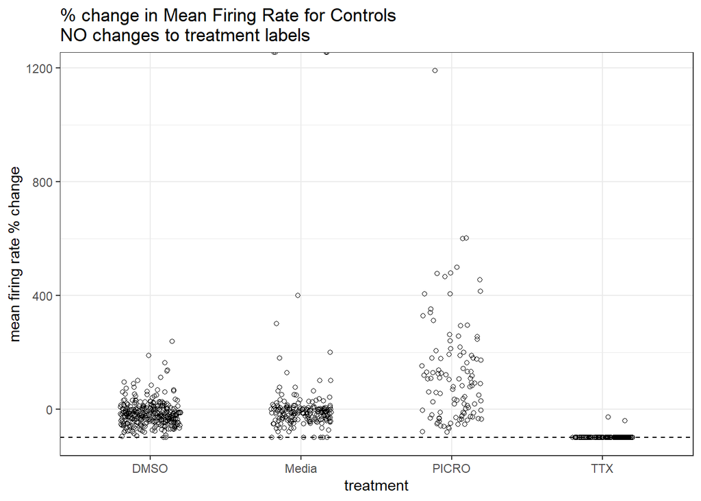

```r
# visually confirm if the PICRO, TTX, LYSIS were added before the second recording for MEA endpoints
# varies across experiments, sometimes across days
plotdat <- dat[treatment %in% c("DMSO","PICRO","TTX","BIC","Media","LYSIS","Lysis","1/2 Lysis") & acnm == "CCTE_Shafer_MEA_acute_firing_rate_mean"]

ggplot(plotdat, aes(x = treatment, y = rval))+
  geom_jitter(width = 0.2, height = 0, pch = 1)+
  ylab('mean firing rate % change')+
  geom_hline(yintercept = -100, lty = 'dashed')+
  theme_bw()+
  ggtitle(paste0('% change in Mean Firing Rate for Controls',
                 '\nNO changes to treatment labels'))
```

If some of the PICRO, TTX, or LYSIS wells look clearly more like the DMSO or Media wells than positive controls, it is possible that those wells did not contain the positive control substance during the second recording and should be re-labelled as ‘Media’. Use your best judgment. Regardless, the PICRO, TTX, and LYSIS wells are not currently used as part of the normalization for the acute MEA data, so it is not the end of the world if these treatment labels are incorrect.

Note that if some individual wells appear way off, check the well quality table to see if these will be excluded regardless.

For the TSCA2019:

- PICRO - seems like some wells responded really well, others not so much. But there isn’t a clearly separation of data points where I would think that some wells did not have PICRO, so I can’t defend an argument to update the treatment labels for the MEA data
- TTX - all but 2 wells had a complete loss of activity, so these treatment labels look correct.
- No data rows associated with the MEA data currently labelled as ‘Lysis’

### AB plates

For cytotoxicity assays, the F1 wells should contain Lysis (usually says “Media” in meta data, since that is correct for the MEA plates). Re-label the treatments to refect this.

However, note that in TCPL the ‘pval’ for the Alamar Blue assay is set to 0. The wells with wllt == ‘p’ are not used as part of the normalization. Therefore, the Lysis wells will be ignored in the Alamar Blue assay. So getting this treatment label correct is not critical.

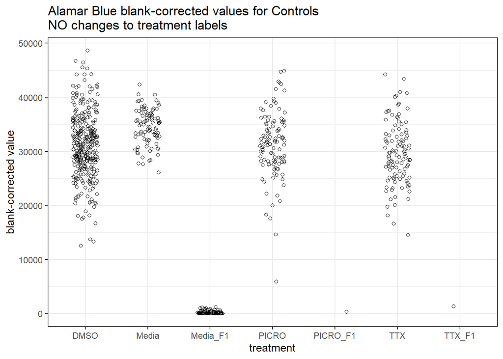

```r
# for Cell Titer Blue assay:
plotdat <- dat[(treatment %in% c("DMSO","PICRO","TTX","BIC","Media","LYSIS","Lysis","1/2 Lysis")
                | (rowi = 6 & coli == 1)) & grepl("(AB)",acnm)]

# Separate out the F1 wells
plotdat[rowi == 6 & coli == 1, treatment := paste0(treatment,'_F1')]

ggplot(plotdat, aes(x = treatment, y = rval))+
  geom_jitter(width = 0.2, height = 0, pch = 1)+
  ylab('blank-corrected value')+
  theme_bw()+
  ggtitle(paste0('Alamar Blue blank-corrected values for Controls',
                 '\nNO changes to treatment labels'))
```

For the TSCA2019:

- Yep, looks all of the F1 wells have a blank-corrected value near 0. Therefore, the treatment in these wells was most likely Lysis.
- PICRO and TTX wells look fairly similar to DMSO, as expected

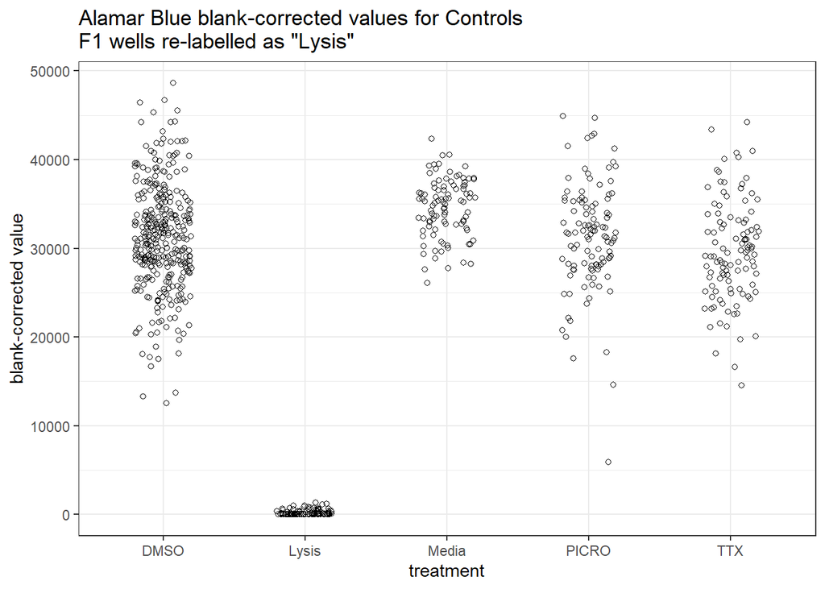

```r
# Update treatment label
dat[grepl("AB",acnm) & rowi == 6 & coli == 1, treatment := 'Lysis']

# View updated plot
plotdat <- dat[(treatment %in% c("DMSO","PICRO","TTX","BIC","Media","LYSIS","Lysis","1/2 Lysis")
                | (rowi = 6 & coli == 1)) & grepl("(AB)",acnm)]

ggplot(plotdat, aes(x = treatment, y = rval))+
  geom_jitter(width = 0.2, height = 0, pch = 1)+
  ylab('blank-corrected value')+
  theme_bw()+
  ggtitle(paste0('Alamar Blue blank-corrected values for Controls',
                 '\nF1 wells re-labelled as "Lysis"'))
```

### LDH plates

Treatments in the LDH wells are generally the same as in the MEA plates and should not need to be updated (see experiment details). Note that in TCPL the ‘pval’ for the LDH assay is defined by the median the Lysis wells on each apid.

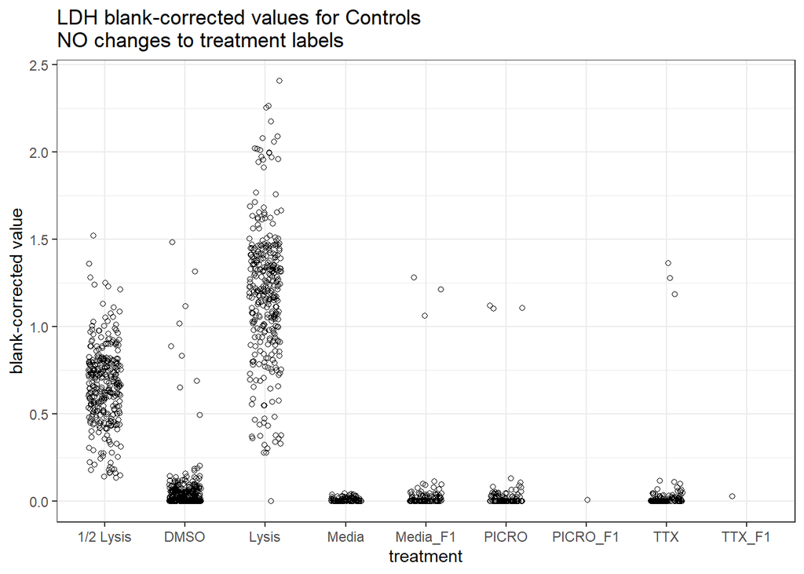

```r
# for LDH assay:
plotdat <- dat[(treatment %in% c("DMSO","PICRO","TTX","BIC","Media","LYSIS","Lysis","1/2 Lysis")
                | (rowi = 6 & coli == 1))
               & grepl("(LDH)",acnm)]

# Separate out the F1 wells
plotdat[rowi == 6 & coli == 1, treatment := paste0(treatment,'_F1')]

ggplot(plotdat, aes(x = treatment, y = rval))+
  geom_jitter(width = 0.2, height = 0, pch = 1)+
  ylab('blank-corrected value')+
  theme_bw()+
  ggtitle(paste0('LDH blank-corrected values for Controls',
                 '\nNO changes to treatment labels'))
```

Median, PICRO, TTX, and F1 wells generally appear similar to DMSO. There are a few outliers, but it’s not worth investigating because the Media, PICRO, and TTX wells are not used to normalize regardless. The outlier DMSO wells are a concern… but if there is no specific well quality note, I have no way of knowing if the wllq or treatment labels should be updated.

Noting DMSO, Media, TTX, and PICRO wells that look more like Lysis wells…

```r
dat[treatment %in% c('DMSO','Media','PICRO','TTX') & rval > 0.25 & grepl('LDH',acnm), .N, by = .(culture_folder, plate.id, treatment, rval)]
```

| culture_folder | plate.id | treatment | rval | N |
| --- | --- | --- | --- | --- |
| 20201104 Culture G1 | MW71-7106 | DMSO | 0.6879667 | 1 |
| 20201104 Culture G1 | MW71-7106 | DMSO | 0.4935667 | 1 |
| 20201104 Culture G1 | MW71-7106 | DMSO | 1.1182667 | 1 |
| 20201104 Culture G1 | MW71-7106 | PICRO | 1.1073667 | 1 |
| 20201104 Culture G1 | MW71-7106 | TTX | 1.1862667 | 1 |
| 20201104 Culture G1 | MW71-7106 | Media | 1.0621667 | 1 |
| 20210120 Culture G6 (198F11 may need repeat) | MW72-8208 | DMSO | 0.8875000 | 1 |
| 20210120 Culture G6 (198F11 may need repeat) | MW72-8208 | DMSO | 0.6524000 | 1 |
| 20210120 Culture G6 (198F11 may need repeat) | MW72-8208 | DMSO | 1.3139000 | 1 |
| 20210120 Culture G6 (198F11 may need repeat) | MW72-8208 | PICRO | 1.1034000 | 1 |

[output cut: 8 more lines]

## Assign spids

Map the treatment names to the sample IDs using the spidmap file. The spidmap data table should be made to contain the following 4 columns:

- treatment = treatment names as they appear in the `dat`
- spid = the sample ID (registered in ChemTrack). There should be a clear, 1-to-1 mapping between every treatment name and spid. The spids usually begin with a prefix such as “EPA”,“EX”, “TP” or “TX” followed by a 6-8 digit code.
- stock_conc = stock concentration
- stock_conc_unit = units of the stock concentration

```r
spidmap <- as.data.table(read.xlsx(spidmap_file, sheet = spid_sheet))
head(spidmap)
```

| ALIQUOT_PLATE_BARCODE | ALIQUOT_WELL_ID | TARGET_CONCENTRATION | TARGET_CONCENTRATION_UNIT | EPA_SAMPLE_ID | ALIQUOT_VOLUME | ALIQUOT_VOLUME_UNIT | ALIQUOT_SOLVENT |
| --- | --- | --- | --- | --- | --- | --- | --- |
| EPAPLT0198 | A01 | 20 | mM | EPAPLT0198A01 | 100 | uL | DMSO |
| EPAPLT0198 | A02 | 20 | mM | EPAPLT0198A02 | 100 | uL | DMSO |
| EPAPLT0198 | A03 | 20 | mM | EPAPLT0198A03 | 100 | uL | DMSO |
| EPAPLT0198 | A04 | 20 | mM | EPAPLT0198A04 | 100 | uL | DMSO |
| EPAPLT0198 | A05 | 20 | mM | EPAPLT0198A05 | 100 | uL | DMSO |
| EPAPLT0198 | A06 | 20 | mM | EPAPLT0198A06 | 100 | uL | DMSO |

```r
# Add the file name
spidmap[, 'spidmap_file' := basename(spidmap_file)]


# Identify the column in the spidmap that contains the sample IDs and rename as "spid"

# Example:
setnames(spidmap, old = 'EPA_SAMPLE_ID', new = 'spid')


# Identify and/or create the column in the spidmap that corresponds to the treatment names in dat (and make this column character)
# Talk to lab technicians is not sure

# Example:
head(unique(dat$treatment))
```

```
## [1] "DMSO"    "198 A06" "198 A08" "198 A10" "PICRO"   "198 A11"
```

```r
# looks like the treatment labels are the same as EPA SAMPLE ID, minus the prefix 'EPAPLT0'.
# so we don't really need the spids in this spidmap, but will merge for formality/to check for missing samples, and to get the concentrations
spidmap[, treatment := sub('EPAPLT0','',spid)]


# Identify and rename the column in spidmap that contains the stock concentration. Confirm that the stock concentration contains a numeric value.

# Example:
names(spidmap)
```

```
##  [1] "ALIQUOT_PLATE_BARCODE"     "ALIQUOT_WELL_ID"
##  [3] "TARGET_CONCENTRATION"      "TARGET_CONCENTRATION_UNIT"
##  [5] "spid"                      "ALIQUOT_VOLUME"
##  [7] "ALIQUOT_VOLUME_UNIT"       "ALIQUOT_SOLVENT"
##  [9] "spidmap_file"              "treatment"
```

```r
unique(spidmap$TARGET_CONCENTRATION) # all 20
```

```
## [1] 20
```

```r
# target concentration is not the same as the actual concentration
# get the actual concentrations from invitrodb
```

Since this spidmap does not contain the stock concentrations, get a table including spid’s and actual concentrations tested from invitrodb

`eval = FALSE` because only need to run once

```r
library(RMySQL)
con <- dbConnect(drv = MySQL(), user = Sys.getenv('INVITRODB_USER_RO'),
                 pass = Sys.getenv('INVITRODB_PASS_RO'),
                 host = Sys.getenv('INVITRODB_HOST'),
                 db = 'invitrodb') # user, pass, etc saved under environmental variables (.Renviron). Modify as needed
all.samples.tb <- dbGetQuery(con, 'SELECT * FROM sample')
setDT(all.samples.tb)
dbDisconnect(con)
TSCA2019.samples.tb <- all.samples.tb[spid %in% spidmap$spid]
write.csv(TSCA2019.samples.tb , file = file.path(project.output.dir,'TSCA2019_sample_tb_from_invitrodb_2023-08-02.csv'))
```

Merge information from `TSCA2019_sample_tb_from_invitrodb_2023-08-02.csv` with the spidmap

```r
TSCA2019.samples.tb <- read.csv(file.path(project.output.dir,'TSCA2019_sample_tb_from_invitrodb_2023-08-02.csv'))
spidmap <- merge(spidmap, TSCA2019.samples.tb, by = 'spid', all.x = T) # stkc = stock concentration
setnames(spidmap, old = 'stkc', new = 'stock_conc')
spidmap[is.na(stock_conc)] # check no NAs for rows that contain spids
```

| spid | ALIQUOT_PLATE_BARCODE | ALIQUOT_WELL_ID | TARGET_CONCENTRATION | TARGET_CONCENTRATION_UNIT | ALIQUOT_VOLUME | ALIQUOT_VOLUME_UNIT | ALIQUOT_SOLVENT | spidmap_file | treatment | X | chid | stock_conc | stkc_unit | tested_conc_unit |
| --- | --- | --- | --- | --- | --- | --- | --- | --- | --- | --- | --- | --- | --- | --- |

```r
# Determine the units of the stock concentrations

# Example:
spidmap[, .N, by =.(stkc_unit)] # mM
```

| stkc_unit | N |
| --- | --- |
| mM | 339 |

```r
setnames(spidmap, old = 'stkc_unit', new = 'stock_conc_unit')


# View the spidmap, determine if any additional cleaning is needed
spidmap
```

| spid | ALIQUOT_PLATE_BARCODE | ALIQUOT_WELL_ID | TARGET_CONCENTRATION | TARGET_CONCENTRATION_UNIT | ALIQUOT_VOLUME | ALIQUOT_VOLUME_UNIT | ALIQUOT_SOLVENT | spidmap_file | treatment | X | chid | stock_conc | stock_conc_unit | tested_conc_unit |
| --- | --- | --- | --- | --- | --- | --- | --- | --- | --- | --- | --- | --- | --- | --- |
| EPAPLT0198A01 | EPAPLT0198 | A01 | 20 | mM | 100 | uL | DMSO | EPA_25092_EPA-Shafer_339_20190722.xlsx | 198A01 | 1 | 25018 | 20.00000 | mM | uM |
| EPAPLT0198A02 | EPAPLT0198 | A02 | 20 | mM | 100 | uL | DMSO | EPA_25092_EPA-Shafer_339_20190722.xlsx | 198A02 | 2 | 24687 | 20.00000 | mM | uM |
| EPAPLT0198A03 | EPAPLT0198 | A03 | 20 | mM | 100 | uL | DMSO | EPA_25092_EPA-Shafer_339_20190722.xlsx | 198A03 | 3 | 30428 | 19.98340 | mM | uM |
| EPAPLT0198A04 | EPAPLT0198 | A04 | 20 | mM | 100 | uL | DMSO | EPA_25092_EPA-Shafer_339_20190722.xlsx | 198A04 | 4 | 25811 | 20.00000 | mM | uM |
| EPAPLT0198A05 | EPAPLT0198 | A05 | 20 | mM | 100 | uL | DMSO | EPA_25092_EPA-Shafer_339_20190722.xlsx | 198A05 | 5 | 20778 | 20.00000 | mM | uM |
| EPAPLT0198A06 | EPAPLT0198 | A06 | 20 | mM | 100 | uL | DMSO | EPA_25092_EPA-Shafer_339_20190722.xlsx | 198A06 | 6 | 40704 | 20.00060 | mM | uM |
| EPAPLT0198A07 | EPAPLT0198 | A07 | 20 | mM | 100 | uL | DMSO | EPA_25092_EPA-Shafer_339_20190722.xlsx | 198A07 | 7 | 20043 | 20.00320 | mM | uM |
| EPAPLT0198A08 | EPAPLT0198 | A08 | 20 | mM | 100 | uL | DMSO | EPA_25092_EPA-Shafer_339_20190722.xlsx | 198A08 | 8 | 22445 | 20.00020 | mM | uM |
| EPAPLT0198A09 | EPAPLT0198 | A09 | 20 | mM | 100 | uL | DMSO | EPA_25092_EPA-Shafer_339_20190722.xlsx | 198A09 | 9 | 44721 | 19.99970 | mM | uM |
| EPAPLT0198A10 | EPAPLT0198 | A10 | 20 | mM | 100 | uL | DMSO | EPA_25092_EPA-Shafer_339_20190722.xlsx | 198A10 | 10 | 23648 | 19.99950 | mM | uM |

[output cut: 329 more lines]

```r
# Check that all test treatments in dat are covered by the spidmap
# (vehicle controls won't have spid's, and that is okay)
setdiff(dat$treatment, spidmap$treatment)
```

```
##  [1] "DMSO"       "198 A06"    "198 A08"    "198 A10"    "PICRO"
##  [6] "198 A11"    "TTX"        "198 B02"    "Media"      "198 B03"
## [11] "Lysis"      "1:250 LDH"  "1:2500 LDH" "1/2 Lysis"
```

```r
# Remove spaces from treatment labels
dat[, treatment := sub('198 ','198',treatment)]
setdiff(dat$treatment, spidmap$treatment)
```

```
## [1] "DMSO"       "PICRO"      "TTX"        "Media"      "Lysis"
## [6] "1:250 LDH"  "1:2500 LDH" "1/2 Lysis"
```

```r
# Add additional spidmaps if needed
# Then rbind into 1 spidmap

# Recheck all treatments covered:
setdiff(dat$treatment, spidmap$treatment)
```

```
## [1] "DMSO"       "PICRO"      "TTX"        "Media"      "Lysis"
## [6] "1:250 LDH"  "1:2500 LDH" "1/2 Lysis"
```

```r
# "0"          "1:250 LDH"  "1:2500 LDH" "DMSO"       "Lysis"      "Media"      "PICRO"      "TTX"        "1/2 Lysis"
# all of these are controls (except for the 0), so this is
```

Check that all treatments in the spidmap are present in the dat

```r
setdiff(spidmap$treatment, dat$treatment)
```

```
##   [1] "198A01" "198A02" "198A03" "198A04" "198A05" "198A07" "198A09" "198A12"
##   [9] "198B01" "198B04" "198B05" "198B06" "198B07" "198B08" "198B10" "198C01"
##  [17] "198C02" "198C03" "198C05" "198C07" "198C12" "198D01" "198D02" "198D03"
##  [25] "198D04" "198D05" "198D06" "198D07" "198D08" "198D10" "198D12" "198E04"
##  [33] "198E08" "198E09" "198E11" "198G07" "198G09" "198G11" "198G12" "198H01"
##  [41] "198H02" "198H03" "198H04" "198H05" "198H06" "198H07" "199A04" "199A12"
##  [49] "199B04" "199B11" "199B12" "199C01" "199C02" "199C03" "199C04" "199C05"
##  [57] "199C06" "199C07" "199C08" "199C09" "199C10" "199C11" "199D01" "199D10"
##  [65] "199F06" "199F07" "199F08" "199F09" "199F11" "199F12" "199G01" "199G02"
##  [73] "199G03" "199G04" "199G06" "199G07" "199G08" "199G09" "199H04" "199H05"
##  [81] "199H06" "199H07" "199H08" "199H11" "200A01" "200A02" "200A03" "200A12"
##  [89] "200B01" "200B02" "200B03" "200B04" "200B05" "200B06" "200B07" "200B08"
##  [97] "200B09" "200B11" "200B12" "200C01" "200C07" "200C09" "200C10" "200C11"
## [105] "200D01" "200D02" "200D05" "200D07" "200D08" "200E01" "200E06" "200E07"
## [113] "200E08" "200E09" "200E10" "200E11" "200E12" "200F02" "200F03" "200F04"
## [121] "200F05" "200F06" "200F07" "200F08" "200F09" "200F10" "200F11" "200F12"
## [129] "200G03" "200G04" "200G05" "200G06" "200G07" "200G09" "200G10" "200H01"
## [137] "200H03" "200H08" "200H11" "200H12" "201A03" "201A05" "201A06" "201B02"
## [145] "201B03" "201B04" "201B05" "201B06" "201C01" "201C04" "201D01" "201D04"
## [153] "201D05" "201E02" "201E03" "201E04" "201E05" "201F02" "201F06" "201G03"
## [161] "201G04" "201G05" "201G06" "201H01" "201H02" "201H03" "201H05" "201H06"
```

```r
# Should be empty IF all treatments in the spidmap are expected to have been tested in this assay
```

TSCA2019 - Several are not present… probably because we did a single point screen first, so many were not screened in multi-conc, so this is not surprising

```r
# Check if every treatment name maps to 1 unique sample ID in spidmap
spidmap[treatment %in% unique(dat$treatment), .N, by = .(treatment)][N > 1]
```

| treatment | N |
| --- | --- |

```r
# Check if every sample ID in spidmap maps to 1 unique treatment
spidmap[treatment %in% unique(dat$treatment), .N, by = .(spid)][N > 1]
```

| spid | N |
| --- | --- |

```r
# Merge the spidmap and dat
dat[, treatment := as.character(treatment)]
spidmap[, treatment := as.character(treatment)]
dat <- merge(dat, spidmap[, .(treatment, spid, stock_conc, stock_conc_unit, spidmap_file)],
             by = 'treatment', all.x = T)


# Assign standardized names for the non-registered control compounds, e.g.: "Tritonx100" "Bicuculline"  "DMSO" "PICRO" "TTX" "MEDIA"
dat[is.na(spid),unique(treatment)]
```

```
## [1] "1/2 Lysis"  "1:250 LDH"  "1:2500 LDH" "DMSO"       "Lysis"
## [6] "Media"      "PICRO"      "TTX"
```

```r
# "0"          "1:250 LDH"  "1:2500 LDH" "DMSO"       "Lysis"      "Media"      "PICRO"      "TTX"        "½ Lysis"
dat[grepl("DMSO",treatment), spid := "DMSO"]
dat[treatment == "Media", spid := "Media"]
dat[treatment == "PICRO", spid := "Picrotoxin"]
dat[treatment == "BIC", spid := "Bicuculline"]
dat[treatment == "TTX", spid := "Tetrodotoxin"]
dat[grepl("Lysis",treatment), spid := "Tritonx100"]
dat[grepl('LDH',treatment), spid := treatment] # will remove these wells regardless

# Final check that a spid assigned for every data row
stopifnot(nrow(dat[is.na(spid)]) == 0)
```

## Assign wllt (well type)

Define the well type (for the ToxCast Pipeline)

- ‘t’ = treated/test well
- ‘n’ = neutral/negative control
- ‘b’ = blank
- ‘p’ = positive control

Not all well types will be present for every assay/experiment. Other wllt definitions are also available (refer to TCPL documentation).

Note that only treatments with wllt == ‘t’ will be fit to a dose response curve and need to have a registered sample ID.

```r
# dmso, water, media
dat[spid %in% c("DMSO","Water"), wllt := "n"]
dat[spid == "Media", wllt := "b"]

# PICRO/BIC - increase firing rate, do not affect CTB/LDH
dat[spid %in% c("Picrotoxin","Bicuculline") & !(acnm %in% c("CCTE_Shafer_MEA_acute_LDH","CCTE_Shafer_MEA_acute_AB")), wllt := "p"] # gain of signal positive control
dat[spid %in% c("Picrotoxin","Bicuculline") & acnm %in% c("CCTE_Shafer_MEA_acute_LDH","CCTE_Shafer_MEA_acute_AB"), wllt := "z"] # filler

# TTX - stops all electrical activity, does not affect CTB/LDH
dat[spid == "Tetrodotoxin" & !(acnm %in% c("CCTE_Shafer_MEA_acute_LDH","CCTE_Shafer_MEA_acute_AB")), wllt := "p"] # loss of signal positive control
dat[spid == "Tetrodotoxin" & acnm %in% c("CCTE_Shafer_MEA_acute_LDH","CCTE_Shafer_MEA_acute_AB"), wllt := "x"] # filler

# Lysis wells
dat[spid == "Tritonx100" & !grepl('(LDH)|(AB)',acnm), wllt := "v"] # viability control
dat[spid == "Tritonx100" & acnm == "CCTE_Shafer_MEA_acute_AB", wllt := "p"] # positive control (but not used for normalization)
# Will finalize the selection of 'p' wells for the LDH assay after verifying concentrations and finalizing the well quality (may vary by plate whether we want the 2 * 1/2 Lysis or full Lysis as the positive control). More details below

# treated compounds
ignore.ldh.treatments <- c('Lysis','1/2 Lysis','1:250 LDH','1:2500 LDH')
dat[is.na(wllt) & !(grepl('LDH',acnm) & treatment %in% ignore.ldh.treatments), .N, by = .(treatment)]
```

| treatment | N |
| --- | --- |
| 198A06 | 945 |
| 198A08 | 945 |
| 198A10 | 945 |
| 198A11 | 945 |
| 198B02 | 945 |
| 198B03 | 945 |
| 198B09 | 644 |
| 198B11 | 644 |
| 198B12 | 644 |
| 198C04 | 644 |

[output cut: 161 more lines]

```r
# yep, all of these look like they are supposed to be test wells
dat[is.na(wllt) & !(grepl('LDH',acnm) & treatment %in% ignore.ldh.treatments), wllt := 't']

# check no NAs
stopifnot(nrow(dat[is.na(wllt) & !(grepl('LDH',acnm) & treatment %in% ignore.ldh.treatments)]) == 0)
```

Well Type Assignments for Control Compounds by assay component:

```r
# summary info
use_acnms <- c("CCTE_Shafer_MEA_acute_AB", "CCTE_Shafer_MEA_acute_LDH", "CCTE_Shafer_MEA_acute_firing_rate_mean")
wllt_summary <- dat[wllt != "t" & acnm %in% use_acnms, .(wllt = paste0(unique(wllt),collapse=",")), by = c("spid","treatment","acnm")]
wllt_summary <- dcast(wllt_summary, treatment + spid ~ acnm, value.var = "wllt", fill = "-")[order(spid)]
setnames(wllt_summary, old = use_acnms, new = c("CellTiter Blue","LDH","MEA components"))
print(wllt_summary)
```

```
##    treatment         spid CellTiter Blue LDH MEA components
## 1:      DMSO         DMSO              n   n              n
## 2:     Media        Media              b   b              b
## 3:     PICRO   Picrotoxin              z   z              p
## 4:       TTX Tetrodotoxin              x   x              p
## 5:     Lysis   Tritonx100              p   -              -
```

Will finalize the selection of ‘p’ wells for the LDH assay after verifying concentrations and finalizing the well quality.

## Check concentrations and units

### Preliminary conc checks

```r
# save original concentration from source data files for reference
dat[, conc_srcf := conc]
dat[, conc := as.numeric(conc)]
```

- Need to get the conc labels for the neural statistics data from the cytodat (because MaestroExperimentLog’s not created for the acute ). But first, confirm that the concs in the LDH and AB data agree by well.

```r
dat[grepl('(LDH)|(AB)',acnm),
    .(num_conc_labels = length(unique(conc))),
    by = .(experiment.date, plate.id, rowi, coli)][num_conc_labels > 1]
```

| experiment.date | plate.id | rowi | coli | num_conc_labels |
| --- | --- | --- | --- | --- |

```r
# (should be empty)
```

- Check for any missing conc labels in wllt == ‘t’ wells

```r
dat[grepl('(LDH)|(AB)',acnm) & (is.na(conc) | conc %in% 0) & wllt == 't', .N, by  = .(treatment, spid, conc, conc_srcf)]
```

| treatment | spid | conc | conc_srcf | N |
| --- | --- | --- | --- | --- |

```r
# (should be empty)
```

- Extrapolate the conc labels for the non-cytotoxicity parameters

```r
dat[!grepl('(LDH)|(AB)',acnm), .N, by = .(conc)] # all currently NA
```

| conc | N |
| --- | --- |
| NA | 228672 |

```r
# extrapolate conc labels
dat[, conc := unique(conc[!is.na(conc)]), by = .(experiment.date, plate.id, rowi, coli)]
dat[is.na(conc) & wllt == 't']  #empty, good
```

| treatment | culture.date | culture_folder | group_char | group_int | experiment.date | apid | plate.id | rowi | coli | acnm | acsn | wllq_by_recording | wllq_notes_by_recording | wllq_ref_by_recording | rval | activity_value.t | activity_value.b | low_ae_flag.b | high_mfr_flag.b | low_mfr_flag.b | date_plate | srcf | conc | full_well_id | full_plate_id | treatment_srcf | expected_wells_per_plate | treatment_tested_only_6_wells_on_plate | spid | … |
| --- | --- | --- | --- | --- | --- | --- | --- | --- | --- | --- | --- | --- | --- | --- | --- | --- | --- | --- | --- | --- | --- | --- | --- | --- | --- | --- | --- | --- | --- | --- |

confirm concentration is defined for every row for test wells (will update controls below)

```r
stopifnot(nrow(dat[is.na(conc) & wllt == 't']) == 0)
```

Confirm no cases where conc == 0 for test wells

```r
stopifnot(nrow(dat[wllt == 't' & conc == 0]) == 0)
```

### Compare conc’s with expected conc based on stock conc & conc index

```r
dat[, conc_log10 := log10(conc)]

# Define the concentration index (cndx)
# Note that the cndx is specific to each plate (plate.id).
# Also note that TCPL also includes the wllt and some additional columns in the 'by' argument for the cndx definition. This cndx in just for our purposes of concentration-checking
dat[, cndx := frank(conc, ties.method = 'dense'),
    by = .(spid, experiment.date, plate.id, acnm)]


# Default dilution scheme shown below
# See e.g., formulas in "Key" Calculations file for the dosing scheme.
# Note that the top concentration in mM from the spidmap is usually the top concentration in uM in the MEA plate.
# If the the scheme is different for a few substances,
# update dilution_factor for individual treatments after merge with dat
dilution.tb <- data.table(cndx = 7:1)
dilution.tb[cndx == 7, dilution_cndx_multiplier := 4.5/3]
dilution.tb[cndx == 6, dilution_cndx_multiplier := 1/2]
dilution.tb[cndx == 5, dilution_cndx_multiplier := 15/(35+15)]
dilution.tb[cndx == 4, dilution_cndx_multiplier := 15/(30+15)]
dilution.tb[cndx == 3, dilution_cndx_multiplier := 15/(35+15)]
dilution.tb[cndx == 2, dilution_cndx_multiplier := 15/(30+15)]
dilution.tb[cndx == 1, dilution_cndx_multiplier := 15/(35+15)]

# Usually, each cndx is based on a fraction of the larger cndx
# However, in this case, cndx 6 is taken directly from the stock conc, rather than cndx 7
dilution.tb[cndx %in% 6:1, dilution_factor := Reduce(f = `*`, dilution_cndx_multiplier, accumulate = TRUE)]
dilution.tb[cndx == 7, dilution_factor := 4.5/3]
dilution.tb
```

| cndx | dilution_cndx_multiplier | dilution_factor |
| --- | --- | --- |
| 7 | 1.5000000 | 1.5000 |
| 6 | 0.5000000 | 0.5000 |
| 5 | 0.3000000 | 0.1500 |
| 4 | 0.3333333 | 0.0500 |
| 3 | 0.3000000 | 0.0150 |
| 2 | 0.3333333 | 0.0050 |
| 1 | 0.3000000 | 0.0015 |

```r
# For TSCA2019 - I know that in G32-35, compounds tested in rows E and F were only tested at the top 6 concentrations
# so I'll shift the cndx by 1 here so that it aligns the the dilution scheme
dat[, treatment_tested_only_6_wells_on_plate := grepl('(G32)|(G33)|(G34)|(G35)',culture_folder) & rowi %in% c(5,6) & coli %in% c(2:4),
    by = .(treatment, experiment.date, plate.id)]

# confirm just 1 treatment per plate is in bottom left
dat[wllt == 't' & grepl('(G32)|(G33)|(G34)|(G35)',culture_folder),
    .(length(unique(treatment[treatment_tested_only_6_wells_on_plate == TRUE]))), by = .(culture_folder, plate.id)][V1 != 1]
```

| culture_folder | plate.id | V1 |
| --- | --- | --- |

```r
#empty, good

dat[treatment_tested_only_6_wells_on_plate == TRUE, .N, by = .(cndx)] # currently 1-6
```

| cndx | N |
| --- | --- |
| 1 | 552 |
| 2 | 552 |
| 3 | 552 |
| 4 | 552 |
| 5 | 552 |
| 6 | 552 |

```r
# want to update to 2-7
dat[treatment_tested_only_6_wells_on_plate == TRUE, cndx := cndx + 1]


# Merge in dilution scheme with dat
dat <- merge(dat, dilution.tb, by = 'cndx', all.x = T)

# Calculate my anticipated concentrations based on dilutions and stock_conc
dat[, top_conc := as.numeric(stock_conc)] # for most treatments, can assume top_conc (in uM) is equal to the stock_conc (in mM).
dat[, my_anticipated_conc := top_conc*dilution_factor]
dat[, my_anticipated_conc_log10 := log10(my_anticipated_conc)]
```

In Carstens et al., 2022, the AC50s from replicates in the acn were found to vary by approximately +/- 0.5 log10 uM. Therefore, I think that any variability in the concentrations due to differences in data processing of decimal places/rounding/stock concentrations in different input files is negligible if it is less that 0.005 log10-uM (2 orders of magnitude lower).

Check for any cases where the conc from the srcf and my_anticipated_conc disagree by more than +/-0.005 log10-uM

```r
# Confirm that the dilution.tb produces decent agreement with the conc_srcf most of the time
dat[, conc_log10_diff_abs := abs(conc_log10 - my_anticipated_conc_log10)]
dat[wllt == 't', .N, by = .(concs_decent_agreement = conc_log10_diff_abs < 0.005)]
```

| concs_decent_agreement | N |
| --- | --- |
| TRUE | 204720 |
| FALSE | 276 |

```r
# good, most conc's agree
```

Check for any cases where the conc from the srcf and my_anticipated_conc disagree by more than +/-0.005 log10-uM

```r
dat[conc_log10_diff_abs >= 0.005, .N,
    by = .(treatment, stock_conc, cndx, conc, my_anticipated_conc, conc_log10_diff_abs, culture_folder)][order(treatment, conc)]
```

| treatment | stock_conc | cndx | conc | my_anticipated_conc | conc_log10_diff_abs | culture_folder | N |
| --- | --- | --- | --- | --- | --- | --- | --- |
| 199E11 | 19.9998 | 7 | 45 | 29.99970 | 0.1760956 | 20210407 Culture G16 | 46 |
| 199E12 | 19.9996 | 7 | 45 | 29.99940 | 0.1761000 | 20210407 Culture G16 | 46 |
| 199F01 | 19.9975 | 7 | 45 | 29.99625 | 0.1761456 | 20210407 Culture G16 | 46 |
| 199F02 | 20.0003 | 7 | 45 | 30.00045 | 0.1760848 | 20210407 Culture G16 | 46 |
| 199F03 | 20.0000 | 7 | 45 | 30.00000 | 0.1760913 | 20210407 Culture G16 | 46 |
| 199F04 | 10.6647 | 7 | 24 | 15.99705 | 0.1761714 | 20210407 Culture G16 | 46 |

Possible reasons for disagreement between conc and my anticipated conc:

- conc’s in source file were not corrected to stock_conc
- conc’s in source file were “corrected” to the wrong stock_conc
- stock_conc in spidmap_files are off (so my_anticipated_conc is off). This is unlikely.
- treatment was intentionally tested at a different series than what is defined in dilution.tb (so my_anticipated_conc is off)
- something else is off with the conc-data alignment

Take appropriate action for each of the cases above

See cases from G16

```r
dat[conc_log10_diff_abs >= 0.005 & treatment != '199B10', .N,
    by = .(treatment, stock_conc, cndx, conc, my_anticipated_conc, conc_log10_diff_abs, culture_folder, plate.id)][order(treatment, conc)]
```

| treatment | stock_conc | cndx | conc | my_anticipated_conc | conc_log10_diff_abs | culture_folder | plate.id | N |
| --- | --- | --- | --- | --- | --- | --- | --- | --- |
| 199E11 | 19.9998 | 7 | 45 | 29.99970 | 0.1760956 | 20210407 Culture G16 | MW75-8105 | 46 |
| 199E12 | 19.9996 | 7 | 45 | 29.99940 | 0.1761000 | 20210407 Culture G16 | MW75-8105 | 46 |
| 199F01 | 19.9975 | 7 | 45 | 29.99625 | 0.1761456 | 20210407 Culture G16 | MW75-8105 | 46 |
| 199F02 | 20.0003 | 7 | 45 | 30.00045 | 0.1760848 | 20210407 Culture G16 | MW75-8105 | 46 |
| 199F03 | 20.0000 | 7 | 45 | 30.00000 | 0.1760913 | 20210407 Culture G16 | MW75-8105 | 46 |
| 199F04 | 10.6647 | 7 | 24 | 15.99705 | 0.1761714 | 20210407 Culture G16 | MW75-8105 | 46 |

```r
#    treatment stock_conc cndx conc my_anticipated_conc conc_log10_diff_abs       culture_folder  plate.id  N
# 1:    199E11    19.9998    7   45            29.99970           0.1760956 20210407 Culture G16 MW75-8105 46
# 2:    199E12    19.9996    7   45            29.99940           0.1761000 20210407 Culture G16 MW75-8105 46
# 3:    199F01    19.9975    7   45            29.99625           0.1761456 20210407 Culture G16 MW75-8105 46
# 4:    199F02    20.0003    7   45            30.00045           0.1760848 20210407 Culture G16 MW75-8105 46
# 5:    199F03    20.0000    7   45            30.00000           0.1760913 20210407 Culture G16 MW75-8105 46
# 6:    199F04    10.6647    7   24            15.99705           0.1761714 20210407 Culture G16 MW75-8105 46
```

Reviewing the lab notebook - there was a dosing error for this plate. Concentrations were intentionally adjusted in the Calculations file to reflect reality.

Updated my_anticipated_conc for G16 and recheck:

```r
# Update dilution factors and re-check
# For cndx 7, 195.5 uL of Media was added to the Dosing plate instead of 295.5 uL
dat[culture.date == 20210407 & plate.id == 'MW75-8105' & cndx == 7,
    dilution_factor := (4.5/(4.5+195.5))*1000/10]
# *1000 because we are multiplying by the stock_conc, which is in mM
# /10 because we dilute 1:10 when add 55 uL to the MEA plate which already has Media in it

dat[, my_anticipated_conc := top_conc*dilution_factor]
dat[, my_anticipated_conc_log10 := log10(my_anticipated_conc)]
dat[, conc_log10_diff_abs := abs(conc_log10 - my_anticipated_conc_log10)]

# Check for any cases where the conc from the srcf and my_anticipated_conc disagree by more than +/-0.005 log10-uM
dat[conc_log10_diff_abs >= 0.005, .N,
    by = .(treatment, stock_conc, cndx, conc, my_anticipated_conc, conc_log10_diff_abs, culture_folder)][order(treatment, conc)]
```

| treatment | stock_conc | cndx | conc | my_anticipated_conc | conc_log10_diff_abs | culture_folder | N |
| --- | --- | --- | --- | --- | --- | --- | --- |

If no conc’s differ from my_anticipated_conc by more than 0.005 OR I know that my_anticipated_conc is correct, set all conc’s to my_anticipated_conc for consistency

```r
dat[, conc := my_anticipated_conc]
```

Confirm that the concentration for a given well is consistent (i.e., is the same for all parameters)

```r
dat[, .(num_concs_per_well = length(unique(conc))), by = .(full_well_id)][num_concs_per_well > 1]
```

| full_well_id | num_concs_per_well |
| --- | --- |

```r
# empty
```

Confirm that there are the expected number of concentrations tested per treatment

```r
# For single-concentration screening check that there is 1 concentration tested per spid
# dat[wllt == 't', .(num_conc_tested = length(unique(conc))), by = .(spid)][num_conc_tested != 1]

# For multi-concentration screening, there should be 7 concentrations per sample (unless the sample was intentionally screened at different doses in different cultures)
dat[wllt == 't', .(num_conc_tested = length(unique(conc))), by = .(spid, treatment)][num_conc_tested != 7]
```

| spid | treatment | num_conc_tested |
| --- | --- | --- |
| EPAPLT0199E11 | 199E11 | 8 |
| EPAPLT0199E12 | 199E12 | 8 |
| EPAPLT0199F01 | 199F01 | 8 |
| EPAPLT0199F02 | 199F02 | 8 |
| EPAPLT0199F03 | 199F03 | 8 |
| EPAPLT0199F04 | 199F04 | 8 |

Hmm, what’s going on here?

```r
check.treatments <- dat[wllt == 't' & treatment != '0',
                        .(num_conc_tested = length(unique(conc))), by = .(spid, treatment)][num_conc_tested != 7, unique(treatment)]
dat[treatment %in% check.treatments, .N, by = .(treatment, cndx, conc)][order(treatment, cndx)]
```

| treatment | cndx | conc | N |
| --- | --- | --- | --- |
| 199E11 | 1 | 0.02999970 | 138 |
| 199E11 | 2 | 0.09999900 | 138 |
| 199E11 | 3 | 0.29999700 | 138 |
| 199E11 | 4 | 0.99998999 | 138 |
| 199E11 | 5 | 2.99996996 | 138 |
| 199E11 | 6 | 9.99989986 | 138 |
| 199E11 | 7 | 44.99954939 | 46 |
| 199E11 | 7 | 29.99969959 | 92 |
| 199E12 | 1 | 0.02999940 | 138 |
| 199E12 | 2 | 0.09999800 | 138 |

[output cut: 38 more lines]

```r
dat[treatment %in% check.treatments, .N, by = .(culture_folder)]
```

| culture_folder | N |
| --- | --- |
| 20210407 Culture G16 | 5796 |

Ah, these are all of the treatments that were misdosed on 1 plate in Group 16. So there were 8 unique concentrations tested. No updates needed.

Update the concentration index after making any corrections above

```r
dat[, cndx := frank(conc, ties.method = 'dense'),
    by = .(spid, experiment.date, plate.id, acnm)]

# Update cndx for treatments in this group / affected plates
dat[, treatment_tested_only_6_wells_on_plate := grepl('(G32)|(G33)|(G34)|(G35)',culture_folder) & rowi %in% c(5,6) & wllt == 't',
    by = .(treatment, experiment.date, plate.id)]
dat[treatment_tested_only_6_wells_on_plate == TRUE, cndx := cndx + 1]
```

### Determine concentration for non-test wells

```r
# View current concentrations
dat[wllt != 't', .N, by = .(spid, conc, conc_srcf, treatment)]
```

| spid | conc | conc_srcf | treatment | N |
| --- | --- | --- | --- | --- |
| DMSO | NA | NA | DMSO | 14292 |
| DMSO | NA | Control | DMSO | 666 |
| Tritonx100 | NA | 0 | Lysis | 109 |
| Tritonx100 | NA | 1 | Lysis | 1 |
| Tritonx100 | NA | 25 | Lysis | 1 |
| Media | NA | NA | Media | 8988 |
| Media | NA | 0 | Media | 305 |
| Picrotoxin | NA | NA | PICRO | 4764 |
| Picrotoxin | NA | 1 | PICRO | 215 |
| Picrotoxin | NA | 25 | PICRO | 6 |

[output cut: 3 more lines]

```r
#             spid conc conc_srcf treatment     N
#  1:         DMSO   NA      <NA>      DMSO 14292
#  2:         DMSO   NA   Control      DMSO   666
#  3:   Tritonx100   NA         0     Lysis   109
#  4:   Tritonx100   NA         1     Lysis     1
#  5:   Tritonx100   NA        25     Lysis     1
#  6:        Media   NA      <NA>     Media  8988
#  7:        Media   NA         0     Media   305
#  8:   Picrotoxin   NA      <NA>     PICRO  4764
#  9:   Picrotoxin   NA         1     PICRO   215
# 10:   Picrotoxin   NA        25     PICRO     6
# 11: Tetrodotoxin   NA      <NA>       TTX  4764
# 12: Tetrodotoxin   NA        25       TTX   215
# 13: Tetrodotoxin   NA         1       TTX     6
# (note that all conc's are currently NA because all conc's were set to my anticipated conc, which is based on the stock_conc, which is not available for the wllt != 't' treatments)

# Median - conc can be NA
dat[spid == "Media", conc := NA_real_]

# Tritonx100 - conc can be NA
# But what are these cases where it is currently 1 or 25?
dat[spid == "Tritonx100" & conc_srcf %in% c(1,25), .N,
    by = .(culture_folder, spid, treatment, treatment_srcf, rowi, coli, acnm, conc_srcf, rval)]
```

| culture_folder | spid | treatment | treatment_srcf | rowi | coli | acnm | conc_srcf | rval | N |
| --- | --- | --- | --- | --- | --- | --- | --- | --- | --- |
| 20210210 Culture G8 | Tritonx100 | Lysis | PICRO | 6 | 1 | CCTE_Shafer_MEA_acute_AB | 1 | 294 | 1 |
| 20210210 Culture G8 | Tritonx100 | Lysis | TTX | 6 | 1 | CCTE_Shafer_MEA_acute_AB | 25 | 1300 | 1 |

```r
#         culture_folder       spid treatment treatment_srcf rowi coli                     acnm conc_srcf rval N
# 1: 20210210 Culture G8 Tritonx100     Lysis          PICRO    6    1 CCTE_Shafer_MEA_acute_AB         1  294 1
# 2: 20210210 Culture G8 Tritonx100     Lysis            TTX    6    1 CCTE_Shafer_MEA_acute_AB        25 1300 1
```

ah, these are some of the F1 wells that I re-labelled as “Lysis” for the AB assay looking at the rvals for the plots before relabelled the F1 wells, these PICRO_F1 and TTX_F1 wells looked a whole lot more like Lysis than picro and ttx only So I’m guessing that both PICRO and TTX were added to these wells in the AB plates. I don’t think this indicates a more concerning data misalignment

```r
dat[spid == "Tritonx100", conc := NA_real_]
```

For DMSO solvent control wells, usually this is 0.1% DMSO i.e., In dosing plate: 5uL of DMSO + 495 uL of Media = (5/500) = 0.01 =1% DMSO Then 1:10 dilution in MEA plate -> 0.1% DMSO Refer to the lab notebook (dilution plate, dosing plate, and experiment protocol sheet) and talk to lab technicians if unsure (Note that in previous level 0 data, the conc may have been entered as 0.001 for DMSO, i.e., the fractional form of 0.1%. But 0.1 is probably better to enter here)

```r
dat[spid == 'DMSO', conc := 0.1]
```

Positive controls:

```r
# Picro
dat[treatment == "PICRO", .N, by = .(conc, conc_srcf)]
```

| conc | conc_srcf | N |
| --- | --- | --- |
| NA | NA | 4764 |
| NA | 1 | 215 |
| NA | 25 | 6 |

```r
#    conc conc_srcf    N
# 1:   NA      <NA> 4764
# 2:   NA         1  215
# 3:   NA        25    6
# IDK, previous notes indicated that there is usually 25 uM of picro
# but here, most wells that defined indicate 1
# Talk to lab technicians, if getting this right matters


# ttx
dat[treatment == "TTX", .N, by = .(conc, conc_srcf)]
```

| conc | conc_srcf | N |
| --- | --- | --- |
| NA | NA | 4764 |
| NA | 25 | 215 |
| NA | 1 | 6 |

```r
#    conc conc_srcf    N
# 1:   NA      <NA> 4764
# 2:   NA        25  215
# 3:   NA         1    6
# Again, IDK. Previous notes indicated that there is usually 1 uM of ttx
# but here, most wells that defined indicate 25
# Talk to lab technicians, if getting this right matters
```

### Concentration units

What to check here:

- For test wells, we want the tested concentration units to match the tested_conc_unit in the spidmap, if available (usually uM)
- For wllt == ‘n’, Note the concentration unit for the vehicle control wells (usually 0.1%)
- For other well types, it’s nice to know the concentration and units, but it’s less important.

```r
# View units that have already been defined
dat[, .N, by = .(wllt, stock_conc_unit)]
```

| wllt | stock_conc_unit | N |
| --- | --- | --- |
| NA | NA | 887 |
| t | mM | 204996 |
| n | NA | 14958 |
| p | NA | 9639 |
| b | NA | 9293 |
| z | NA | 221 |
| x | NA | 221 |

The vast majority of treatments will be in uM.

```r
# If available, check the expected tested conc unit (from invitrodb sample table) for test wells from the spidmap
spidmap[, .N, by = .(tested_conc_unit)]
```

| tested_conc_unit | N |
| --- | --- |
| uM | 339 |

```r
# tested_conc_unit   N
# 1:               uM 339
# all uM.
# all treatments shoudl be in uM as well

# For test wells, if the stock_conc_unit are mM, then the units for the MEA and cytotoxicity data are usually uM (micromolar)
dat[wllt == 't' & stock_conc_unit == 'mM', units := 'uM']

# Sometimes, the units may not be in a molar value.
# For example, if the stock conc is in mg/mL, then the test units are likely in ug/mL
# If the molecular weight is known, convert these values to uM.
# Otherwise, note the actual units

# For vehicle control wells, units are '%'
dat[spid == 'DMSO', units := '%']

# For other controls..
dat[!wllt %in% c('t','n'), .N, by = .(treatment, wllt, conc, units)][order(treatment)]
```

| treatment | wllt | conc | units | N |
| --- | --- | --- | --- | --- |
| 1/2 Lysis | NA | NA | NA | 332 |
| 1:250 LDH | NA | NA | NA | 111 |
| 1:2500 LDH | NA | NA | NA | 111 |
| Lysis | p | NA | NA | 111 |
| Lysis | NA | NA | NA | 333 |
| Media | b | NA | NA | 9293 |
| PICRO | p | NA | NA | 4764 |
| PICRO | z | NA | NA | 221 |
| TTX | p | NA | NA | 4764 |
| TTX | x | NA | NA | 221 |

```r
#      treatment wllt conc units    N
#  1:  1/2 Lysis <NA>   NA  <NA>  332
#  2:  1:250 LDH <NA>   NA  <NA>  111
#  3: 1:2500 LDH <NA>   NA  <NA>  111
#  4:      Lysis    p   NA  <NA>  111
#  5:      Lysis <NA>   NA  <NA>  333
#  6:      Media    b   NA  <NA> 9293
#  7:      PICRO    p   NA  <NA> 4764
#  8:      PICRO    z   NA  <NA>  221
#  9:        TTX    p   NA  <NA> 4764
# 10:        TTX    x   NA  <NA>  221

# Lysis, Media, and LDH can definitely be left as NA
# I think PICRO and TTX would be in uM, but IDK the conc's
# either way, the units matter more for the

# View updated units
dat[, .N, by = .(wllt, units, stock_conc_unit)]
```

| wllt | units | stock_conc_unit | N |
| --- | --- | --- | --- |
| NA | NA | NA | 887 |
| t | uM | mM | 204996 |
| n | % | NA | 14958 |
| p | NA | NA | 9639 |
| b | NA | NA | 9293 |
| z | NA | NA | 221 |
| x | NA | NA | 221 |

## Finalize well quality

### Add wllq by well

```r
wllq.tb.by.well.file <- file.path(project.output.dir, paste0(project_name,'_well_quality_table_by_well.csv'))

# define the "assay" for every row of dat
dat[grepl("LDH",acnm), assay := 'LDH']
dat[grepl("AB",acnm), assay := 'AB']
dat[is.na(assay), assay := 'ACN'] # ACN = ACute Neural Network activity

# Run function to update well quality by well
dat <- add_wllq_by_well(dat,
                        wllq.tb.by.well.file,
                        num_rows_per_plate = 6,
                        num_columns_per_plate = 8)
```

```
##
## Some rows in  TSCA2019_well_quality_table_by_well.csv  did not match any rows in dat:
##     plate.id culture.date assay rowi coli N
## 1: MW75-8114     20210414   LDH    7    3 1
```

```
## Warning in add_wllq_by_well(dat, wllq.tb.by.well.file, num_rows_per_plate = 6,
## : Some rows in TSCA2019_well_quality_table_by_well.csv did not match any rows
## in dat. These will be ignored.
```

```r
# Some rows in  TSCA2019_well_quality_table_by_well.csv  did not match any rows in dat:
#     plate.id culture.date assay rowi coli N
# 1: MW75-8114     20210414   LDH    7    3 1
# Warning message:
# In add_wllq_by_well(dat, wllq.tb.by.well.file, num_rows_per_plate = 6,  :
#   Some rows in TSCA2019_well_quality_table_by_well.csv did not match any rows in dat. These will be ignored.
```

Well G3 (rowi = 7, coli = 3) is a blank well. It is not usually included in the blank-corrected optical density values. I mostly included this row in the well quality table to inform the calculation of the blank-corrected values in this script. This warning message can be ignored.

### Add wllq by treatment, cndx, and culture date

```r
wllq.tb.by.trt.file <- file.path(project.output.dir,                                   paste0(project_name,'_well_quality_table_by_treatment_cndx_culture_date.csv'))

# define the "assay" for every row of dat
dat[grepl("LDH",acnm), assay := 'LDH']
dat[grepl("AB",acnm), assay := 'AB']
dat[is.na(assay), assay := 'acn']

# Run function to update well quality
dat <- add_wllq_by_treatment_cndx_culture_date(dat, wllq.tb.by.trt.file)
```

```
## no notes in TSCA2019_well_quality_table_by_treatment_cndx_culture_date.csv apply to the assays in dat ( AB,ACN,LDH ).
## Defaulting to wllq_by_trt = 1
```

### Merge all wllq columns

```r
# Take the minimum wllq across all wllq columns
dat[, wllq := pmin(wllq_by_recording, wllq_by_well, wllq_by_trt, na.rm = T)]

# Merge wllq notes and ref
dat[, wllq_notes := paste0(ifelse(is.na(wllq_notes_by_recording), '', wllq_notes_by_recording),
                           '; ',
                           ifelse(is.na(wllq_notes_by_well), '', wllq_notes_by_well),
                           '; ',
                           ifelse(is.na(wllq_notes_by_trt), '', wllq_notes_by_trt))]
dat[, wllq_ref := paste0(ifelse(is.na(wllq_ref_by_recording), '', wllq_ref_by_recording),
                         '; ',
                         ifelse(is.na(wllq_ref_by_well), '', wllq_ref_by_well),
                         '; ',
                         ifelse(is.na(wllq_ref_by_trt), '', wllq_ref_by_trt))]

# remove leading or redundant "; "
dat[, wllq_notes := sub('; ;',';',wllq_notes)]
dat[, wllq_ref := sub('; ;',';',wllq_ref)]
dat[, wllq_notes := sub('^; ','',wllq_notes)]
dat[, wllq_ref := sub('^; ','',wllq_ref)]
```

Confirm that the wllq and notes appear as expected

```r
dat[, .N, by = .(wllq, wllq_notes, wllq_ref)][order(wllq)]
```

| wllq | wllq_notes | wllq_ref | N |
| --- | --- | --- | --- |
| 0 | dosing error, added 155uL dosing solution to columns 1-4 [instead of 55uL]; | lab notebook; | 752 |
| 0 | Baseline MFR < 0.6377603 Hz; dosing error, added 155uL dosing solution to columns 1-4 [instead of 55uL]; | activity level cutoffs; lab notebook; | 688 |
| 0 | Baseline MFR < 0.6377603 Hz; ; | activity level cutoffs; | 22211 |
| 0 | Baseline MFR > 3.4036511 Hz; ; | activity level cutoffs; | 12697 |
| 0 | Baseline MFR < 0.6377603 Hz; Baseline # of AE < 10; ; |  | 560 |
| 0 | Baseline # of AE < 10; Baseline MFR < 0.6377603 Hz; ; | activity level cutoffs; | 7491 |
| 0 | Baseline # of AE < 10; ; | activity level cutoffs; | 4781 |
| 0 | Baseline MFR < 0.6377603 Hz; Baseline # of AE < 10; plate has low controls quality, noted in lab notebook QC notes. Will evaluate; | lab notebook; | 240 |
| 0 | Baseline MFR > 3.4036511 Hz; plate has low controls quality, noted in lab notebook QC notes. Will evaluate; | activity level cutoffs; lab notebook; | 6952 |
| 0 | Baseline # of AE < 10; Baseline MFR < 0.6377603 Hz; plate has low controls quality, noted in lab notebook QC notes. Will evaluate; | activity level cutoffs; lab notebook; | 3564 |

[output cut: 6 more lines]

### Note NA and infinite rvals

```r
dat[is.na(rval), .N, by = .(wllq, assay)]
```

| wllq | assay | N |
| --- | --- | --- |
| 0 | ACN | 5461 |
| 1 | ACN | 6569 |

```r
#    wllq assay    N
# 1:    0   ACN 5461
# 2:    1   ACN 6569

# rval is usually NA for the ACN assay where either the baseline or treated recording value is NA
# or if both the baseline and treated recording value are 0 (hence 0/0)
# for a given well + parameter

# Previously, I set the wllq to 0 wherever the rval is NA
# However, there isn't necessarily anything wrong with these wells
# So, perhaps we can leave wllq as-is, knowing that TCPL will ignore data points with NA rval regardless.
# (I think NA rvals are set to wllq == 0 at level 2 of TCPL)

# Inf
dat[is.infinite(rval), .N, by = .(wllq, assay)]
```

| wllq | assay | N |
| --- | --- | --- |
| 0 | ACN | 105 |
| 1 | ACN | 187 |

```r
#    wllq assay   N
# 1:    0   ACN 105
# 2:    1   ACN 187

#this occurs when the baseline recording is 0 (so the percent change rval is x/0)
dat[is.infinite(rval), .N, by = .(activity_value.b == 0)]
```

| activity_value.b | N |
| --- | --- |
| TRUE | 292 |

```r
# activity_value.b   N
# 1:             TRUE 292

# I think that infinite rvals will cause issues with TCPL,
# so we'll set the wllq to 0 in these cases
dat[is.infinite(rval), `:=` (wllq = 0,
                             wllq_notes = paste0("Baseline activity is 0, rval is Inf; ", wllq_notes))]
```

```r
stopifnot(nrow(dat[is.na(wllq)]) == 0)
```

## Prepare LDH p wells

Background:

What I’ve done in the past:

- For plates that have at least one 1/2 Lysis well with wllq=1,
  - multiply the 1/2 Lysis rval’s by 2 and set wllt = “p”
  - set wllt for Full Lysis wells to “x” (We don’t want these to be part of the “p” wells on these plates)
- For plates that do not have at least one 1/2 Lysis well with wllq=1,
  - Label full Lysis wells as wllt = “p”

HOWEVER, based on more recent conversations with Kathleen, it may be better to consider each plate individually to determine whether the Full or Half lysis wells should be used. SO, we may want to have some conversations about how to determine which wells should be used as the positive controls for the LDH assay, perhaps based on some standardized cutoff.

What’s been done for the LDH in the past:

```r
# View lysis-related treatment names for LDH plates
dat[grepl('LDH',acnm) & grepl('lysis',tolower(treatment)), .N, by = .(treatment)]
```

| treatment | N |
| --- | --- |
| Lysis | 333 |
| 1/2 Lysis | 332 |

```r
#        treatment   N
# 1:         Lysis 333
# 2:     1/2 Lysis 332

# Determine which plates have at least 1 1/2 lysis well with wllq == 1
dat[grepl('LDH',acnm),
    any_half_lysis_wllq1 := any(treatment == '1/2 Lysis' & wllq == 1),
    by = .(experiment.date, plate.id)]

# How many plates have any 1/2 Lysis wells?
dat[grepl('LDH',acnm), .(num_plates = length(unique(full_plate_id))), by = .(any_half_lysis_wllq1)]
```

| any_half_lysis_wllq1 | num_plates |
| --- | --- |
| TRUE | 111 |

```r
# any_half_lysis_wllq1 num_plates
# 1:                 TRUE        111
# all do

# For plates that have at least one 1/2 Lysis well with wllq=1,
# - multiply the 1/2 Lysis values by 2 and set wllt = "p"
# - set wllt for Full Lysis wells to "x" (We don't want these to be part of the "p" wells on these plates)
dat[grepl('LDH',acnm) & any_half_lysis_wllq1 == TRUE
    & treatment == '1/2 Lysis',
    `:=`(treatment = paste0("2 * ",treatment),
         rval = 2*rval,
         wllt = "p")]
dat[grepl('LDH',acnm) & any_half_lysis_wllq1 == TRUE
    & treatment == 'Lysis',
    `:=`(wllt = "x")]

# For plates that do not have at least one 1/2 Lysis well with wllq=1,
# - label full Lysis wells as wllt = "p"
dat[grepl('LDH',acnm) & any_half_lysis_wllq1 == FALSE
    & treatment == 'Lysis',
    `:=`(wllt = "p")]

# Check every LDH plate has at least 1 wllt == 'p' well
dat[grepl('LDH',acnm),
    .(treatments_wllt_p = paste0(sort(unique(treatment[wllt %in% 'p'])))),
    by = .(full_plate_id)][, .N, by = .(treatments_wllt_p)]
```

| treatments_wllt_p | N |
| --- | --- |
| 2 * 1/2 Lysis | 111 |

```r
# treatments_wlltp   N
# 1:    2 * 1/2 Lysis 111
# looks good
```

Remove LDH positive control wells, because I’m not sure how to assign the conc, wllt (can’t be ‘p’) or spid

```r
dat <- dat[!treatment %in% c("1:250 LDH","1:2500 LDH")]
```

## Check all acnm are registered in invitrodb

Note that different maestros/Neural Statistics Compilers (and possibly different axis versions) will output slightly different subsets of endpoints. So, just want to check that there are no unexpected new endpoints.

```r
acsn_map[acnm %in% unique(dat$acnm), .N, by = .(Status_2023.05.12)]
```

| Status_2023.05.12 | N |
| --- | --- |
| registered in invitrodb | 48 |
| not registered in invitrodb | 1 |

```r
# Status_2023.05.12  N
# 1:     registered in invitrodb 48
# 2: not registered in invitrodb  1

acsn_map[acnm %in% unique(dat$acnm) & Status_2023.05.12 == 'not registered in invitrodb',
         .(acsn, acnm, Category)]
```

| acsn | acnm | Category |
| --- | --- | --- |
| Network ISI Coefficient of Variation | CCTE_Shafer_MEA_acute_per_network_burst_interspike_interval_cv | network bursts |

```r
#                                    acsn                                                           acnm       Category
# 1: Network ISI Coefficient of Variation CCTE_Shafer_MEA_acute_per_network_burst_interspike_interval_cv network bursts
```

IDK why this endpoint hasn’t been registered. Not sure if it’s worth including now

Any assay components in the map that we would expect to see in dat, but not there?

```r
# Acnm in ascn_map, not in dat
acsn_map[!acnm %in% unique(dat$acnm), .(acsn, acnm, Category, Status_2023.05.12)]
```

| acsn | acnm | Category | Status_2023.05.12 |
| --- | --- | --- | --- |
| Resistance - Avg (kΩ) | CCTE_Shafer_MEA_acute_resistance_avg | impedance | not registered in invitrodb |
| Resistance - Std (kΩ) | CCTE_Shafer_MEA_acute_resistance_std | impedance | not registered in invitrodb |
| Number of Covered Electrodes | CCTE_Shafer_MEA_acute_electrodes_covered_number | impedance | not registered in invitrodb |
| Weighted Mean Resistance (kΩ) | CCTE_Shafer_MEA_acute_resistance_mean_weighted | impedance | not registered in invitrodb |

```r
#                             acsn                                            acnm  Category           Status_2023.05.12
# 1:         Resistance - Avg (kΩ)            CCTE_Shafer_MEA_acute_resistance_avg impedance not registered in invitrodb
# 2:         Resistance - Std (kΩ)            CCTE_Shafer_MEA_acute_resistance_std impedance not registered in invitrodb
# 3:  Number of Covered Electrodes CCTE_Shafer_MEA_acute_electrodes_covered_number impedance not registered in invitrodb
# 4: Weighted Mean Resistance (kΩ)  CCTE_Shafer_MEA_acute_resistance_mean_weighted impedance not registered in invitrodb
```

This is fine, these are for the impedance only

```r
# Note total parameters
dat[, param_per_plate := length(unique(acnm)), by = .(full_plate_id)]

dat[, .(num_plates = length(unique(full_plate_id))), by = .(param_per_plate)]
```

| param_per_plate | num_plates |
| --- | --- |
| 45 | 32 |
| 46 | 77 |
| 2 | 2 |

```r
#    param_per_plate num_plates
# 1:              45         32
# 2:              46         77
# 3:               2          2
```

This variability is probably due to variability in the axis version / maestro type / axis settings. I’m not even sure if the plates with 46 contain the same 45 + 1 as the plates that contain 45, or if there is additional variability.

Let’s just check that the 17 (15 + 2 cyto) main endpoints are present for every plate

```r
main.params <- acsn_map[Status_invitroDBv3.5 == 'export_ready=1',unique(acnm)]
length(main.params) # 17
```

```
## [1] 17
```

```r
res <- dat[, .(missing_params = paste0(setdiff(main.params, acnm),collapse = ","),
               num_missing_params = length(setdiff(main.params, acnm))),
           by = .(full_plate_id)]
res[missing_params != '', .(full_plate_id, num_missing_params)]
```

| full_plate_id | num_missing_params |
| --- | --- |
| 20201125_MW71-7113 | 15 |
| 20210512_MW75-8213 | 15 |

```r
#        full_plate_id num_missing_params
# 1: 20201125_MW71-7113                 15
# 2: 20210512_MW75-8213                 15
```

These are the 2 plates where the neural stats file was split.

So cool, no other plates are missing any of the main parameters that were released in v3.5

## Note the vehicle controls per plate

Check if any plates have multiple vehicle controls. If there are multiple vehicle controls used on a given plate (or apid), then we might want to reconsider the apid definition for that apid so that treatments are normalized to wells with the same solvent. However, in the small data sets analyzed so far, we have not found a notable difference in activity between DMSO, Water, and Ethanol wells in the NFA so far, so the vehicle solvent type may not be too critical.

```r
# Check if any plates have multiple vehicle controls
# (if multiple are present on a given plate, consider the normalization method and/or apid definition for the given plate)
dat[, num_vehicle_control_types_per_plate := length(unique(treatment[wllt == 'n'])), by = .(full_plate_id)]
stopifnot(nrow(dat[num_vehicle_control_types_per_plate > 1]) == 0)

# View the vehicle controls on these plates
# dat[num_vehicle_control_types_per_plate > 1 & wllt == 'n', .N, by = .(full_plate_id, treatment, spid)]
```

## Data usability checks - percent change in controls MFR within +/- 2 SD of mean

In previous project, a final well quality check was performed on the DMSO control wells to remove outliers in the MFR % change values (as opposed to the automated wllq updates based on the activity level in the baseline recording only).

What has been done for the all projects that have been pipelined to-date (‘APCRA2019’,‘DNT2019’,‘GF2019’,‘ToxCast2016’):

- Calculate the mean and SD where wllt == ‘n’ for ALL MEA acute data pre-processed to date
- Set wllq to 0 for any wells where the CCTE_Shafer_MEA_acute_firing_rate_mean is less than 2 SDs below the mean or more then 2 SDs above the mean for all parameters

I think that this approach was developed mostly to justify removing several low-activity control wells from the APCRA2019/DNT2019 projects. The idea was that as new data is added, the mean and SD of wllt == ‘n’ wells would be recalculated and the well quality would be reset for all existing MEA Acute data.

HOWEVER, this approach may not be preferable going forward because:

- If we have to update the mean and SD based on all wllt == ‘n’ wells for ALL MEA acute data every time a new project is added, then the well quality for some wells that have already been pipelined might change.
- I’m not sure that it makes sense to set the wllq to 0 for the LDH and AB parameters based on the MFR, particularly where the MFR is 2SD above the mean.

Some alternative options going forward:

- We could use the data quality threshold from the NFA (exclude plates where plate-wise median of controls on DIV 12 is < 10 spikes per min or < 2 active electrodes).
- We could set the standardized cutoffs based on only the MEA Acute data that has already been pipelined, and not update the cutoffs as more data is added.

Replicating the analysis that was done for previous projects with TSCA2019 integrated (previously implemented in `remove_dmso_outliers()`):

```r
# Load data sets that have already been pipelined
# With previous script configuration, 'dat4' was the final output for the run_me for each project,
# except that WLLQ had NOT yet be set to 0 for outlier DMSO wells.
# WLLQ was set to 0 for outlier DMSO wells in mea-acute-neural-stats-to-mc0-scripts/deprecated_create_lvl0_snapshots.R.
# The output from that script saved 2 tables under lvl0_snapshots/:
# lvl0_snapshots/dat4_2020-07-29.RData and
# lvl0_snapshots/mea_acute_lvl0_2020-07-29.RData
all.prev.dat <- data.table()
load('APCRA2019/output/APCRA2019_dat4_2020-07-27.RData') # getting most recent file
dat4[, project := 'APCRA2019']
all.prev.dat <- rbind(all.prev.dat, dat4)
load('DNT2019/output/DNT2019_dat4_2020-07-27.RData') # getting most recent file
dat4[, project := 'DNT2019']
all.prev.dat <- rbind(all.prev.dat, dat4)
load('GF2019/output/GF2019_dat4_2020-07-27.RData') # getting most recent file
dat4[, project := 'GF2019']
all.prev.dat <- rbind(all.prev.dat, dat4)
load('ToxCast2016/output/ToxCast2016_dat4_2020-07-27.RData') # getting most recent file
dat4[, project := 'ToxCast2016']
all.prev.dat <- rbind(all.prev.dat, dat4)
rm(dat4)

# Add the current data file to alldat
dat[, project := project_name]
alldat <- rbind(all.prev.dat, dat, fill = T)

# Calculate the mean, sd of the control wells
alldat[, wlltn_mean := mean(rval[wllq == 1 & wllt == 'n'], na.rm = T), by = .(acnm)]
alldat[, wlltn_SD := sd(rval[wllq == 1 & wllt == 'n'], na.rm = T), by = .(acnm)]
alldat[, wlltn_lower_bound := wlltn_mean - 2 * wlltn_SD]
alldat[, wlltn_upper_bound := wlltn_mean + 2 * wlltn_SD]

# How many control wells that currently have wllq == 1 would have wllq set to 0 because MFR is too low?
alldat[acnm == "CCTE_Shafer_MEA_acute_firing_rate_mean" & wllt == 'n' & wllq == 1 & rval < wlltn_lower_bound,
       .N, by = .(project, wlltn_mean, wlltn_SD)]
```

| project | wlltn_mean | wlltn_SD | N |
| --- | --- | --- | --- |
| APCRA2019 | -27.95468 | 32.47011 | 4 |
| DNT2019 | -27.95468 | 32.47011 | 8 |
| TSCA2019 | -27.95468 | 32.47011 | 4 |

```r
#      project wlltn_mean wlltn_SD N
# 1: APCRA2019  -27.95468 32.47011 4
# 2:   DNT2019  -27.95468 32.47011 8
# 3:  TSCA2019  -27.95468 32.47011 4
# only a few

# How many control wells that currently have wllq == 1  would have wllq set to 0 because MFR is too high?
alldat[acnm == "CCTE_Shafer_MEA_acute_firing_rate_mean" & wllt == 'n' & wllq == 1 & rval > wlltn_upper_bound,
       .N, by = .(project, wlltn_mean, wlltn_SD)]
```

| project | wlltn_mean | wlltn_SD | N |
| --- | --- | --- | --- |
| APCRA2019 | -27.95468 | 32.47011 | 4 |
| TSCA2019 | -27.95468 | 32.47011 | 19 |

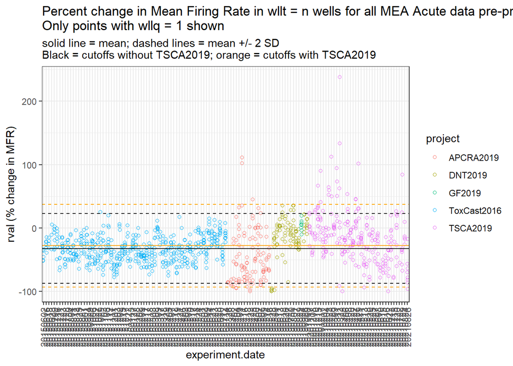

```r
#      project wlltn_mean wlltn_SD  N
# 1: APCRA2019  -27.95468 32.47011  4
# 2:  TSCA2019  -27.95468 32.47011 19

# Thresholds without TSCA2019
alldat[, wlltn_mean_sans_tsca2019 := mean(rval[wllq == 1 & wllt == 'n' & project != 'TSCA2019'], na.rm = T), by = .(acnm)]
alldat[, wlltn_SD_sans_tsca2019 := sd(rval[wllq == 1 & wllt == 'n' & project != 'TSCA2019'], na.rm = T), by = .(acnm)]
alldat[, wlltn_lower_bound_sans_tsca2019 := wlltn_mean_sans_tsca2019 - 2 * wlltn_SD_sans_tsca2019]
alldat[, wlltn_upper_bound_sans_tsca2019 := wlltn_mean_sans_tsca2019 + 2 * wlltn_SD_sans_tsca2019]


# Visualize
plotdat <- alldat[wllt == 'n' & acnm == "CCTE_Shafer_MEA_acute_firing_rate_mean" & wllq == 1]
ggplot(plotdat, aes(x = experiment.date, y = rval))+
  geom_jitter(aes(color = project), width = 0.1, height = 0, pch = 1)+

  # without TSCA2019
  geom_hline(aes(yintercept = wlltn_mean_sans_tsca2019))+
  geom_hline(aes(yintercept = wlltn_lower_bound_sans_tsca2019), lty = 'dashed')+
  geom_hline(aes(yintercept = wlltn_upper_bound_sans_tsca2019), lty = 'dashed')+

  # with tSCA2019
  geom_hline(aes(yintercept = wlltn_mean), color = 'orange')+
  geom_hline(aes(yintercept = wlltn_lower_bound), lty = 'dashed', color = 'orange')+
  geom_hline(aes(yintercept = wlltn_upper_bound), lty = 'dashed', color = 'orange')+

  ylab('rval (% change in MFR)')+
  theme_bw()+
  theme(axis.text.x = element_text(angle = 90, vjust = 0.5))+
  ggtitle('Percent change in Mean Firing Rate in wllt = n wells for all MEA Acute data pre-processed to-date\nOnly points with wllq = 1 shown',
          subtitle = c(paste0('solid line = mean; dashed lines = mean +/- 2 SD',
                              '\nBlack = cutoffs without TSCA2019; orange = cutoffs with TSCA2019')))
```

So, it looks like the cutoffs with TSCA2019 (orange) are less stringent than those without TSCA2019 (black). So if we used this approach, then the wllq for some previously pipelined data would be updated to wllq := 1

Update the wllq for TSCA2019 and/or previous data sets as desired :)

## For repeated treatments, determine which culture(s) to keep

Sometimes a treatment is repeated in multiple cultures within a project. This is usually due to some unwanted results in the first culture, e.g., high variability, precipitate, or cytotoxicity. In any case, discuss with lab which culture(s) we want to keep for each repeated treatment. Make graphs to visualize as needed. For cultures that we don’t want to keep for a given treatment, set wllq := 0 and add a wllq_note.

```r
# define the "assay" for every row of dat
dat[grepl("LDH",acnm), assay := 'LDH']
dat[grepl("AB",acnm), assay := 'AB']
dat[is.na(assay), assay := 'ACN']

# Identify treatments tested in multiple cultures for a given assay
dat[wllq == 1 & wllt == 't', .(num_cultures = length(unique(culture.date)),
                               cultures = paste0(sort(unique(culture.date)),collapse = ",")),
    by = .(treatment, assay)][num_cultures > 1][order(treatment, assay)]
```

| treatment | assay | num_cultures | cultures |
| --- | --- | --- | --- |
| 198F11 | AB | 3 | 20210120,20210602,20210811 |
| 198F11 | ACN | 3 | 20210120,20210602,20210811 |
| 198F11 | LDH | 3 | 20210120,20210602,20210811 |
| 198H11 | AB | 3 | 20210210,20210602,20210811 |
| 198H11 | ACN | 3 | 20210210,20210602,20210811 |
| 198H11 | LDH | 3 | 20210210,20210602,20210811 |
| 198H12 | AB | 3 | 20210210,20210602,20210811 |
| 198H12 | ACN | 3 | 20210210,20210602,20210811 |
| 198H12 | LDH | 3 | 20210210,20210602,20210811 |
| 199A01 | AB | 4 | 20210210,20210609,20210707,20210811 |

[output cut: 89 more lines]

Note the names of the culture folders may indicate which treatments the lab technicians flagged as needing to be repeated (and so discarded?)

E.g., “20210310 Culture G12 (all but 199B10 need repeat)” may indicate that all treatments except 199B10 should have wllq == 0 for this group?

Example plot for 1 compound:

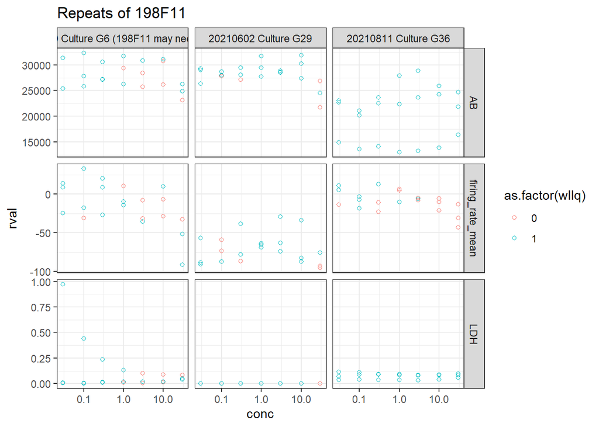

```r
dat[, acnm_short := sub('CCTE_Shafer_MEA_acute_','',acnm)]

view_treatment <- '198F11'
plotdat <- dat[treatment == view_treatment & acnm %in% paste0('CCTE_Shafer_MEA_acute_',c('LDH','AB','firing_rate_mean'))]

ggplot(plotdat,
       aes(x = conc, y = rval))+
  geom_point(aes(color = as.factor(wllq)), pch = 1)+
  scale_x_log10()+
  facet_grid(rows = vars(acnm_short), cols = vars(culture_folder), scales = 'free')+
  theme_bw()+
  ggtitle(paste0('Repeats of ',view_treatment))
```

## Confirm every treatment has at least 4 conc’s with wllq=1

Samples with usable data from less than 4 concentrations will not be fit to a curve in TCPL.

```r
# Use mean firing rate as a representative MEA parameter that cannot be NA and would have very few infinite rvals
usable.concs.tb <- dat[acnm == 'CCTE_Shafer_MEA_acute_firing_rate_mean',
                       .(num_usable_concs = length(unique(conc[wllq == 1]))),
                       by = .(treatment, wllt)]

usable.concs.tb[wllt == 't', .N, by = .(num_usable_concs)][order(num_usable_concs)]
```

| num_usable_concs | N |
| --- | --- |
| 4 | 4 |
| 5 | 1 |
| 6 | 9 |
| 7 | 151 |
| 8 | 6 |

```r
treatments.less.than.4.concs <- usable.concs.tb[wllt == 't' & num_usable_concs < 4, unique(treatment)]
treatments.less.than.4.concs
```

```
## character(0)
```

The above treatments (if any) with wllq == 1 data for less than 4 conc’s will not have any dose-response curves generated in TCPL. Confirm with lab technicians that these compounds were not retested elsewhere and that it is okay that we don’t have any data for these.

What well quality issues lead to no data for these treatments?

```r
dat[treatment %in% treatments.less.than.4.concs, .N, by = .(culture_folder, wllq, wllq_notes)][order(culture_folder, -N)]
```

| culture_folder | wllq | wllq_notes | N |
| --- | --- | --- | --- |

## Check for the expected number of technical replicates for every treatment-conc-culture

Usually there are 3 technical replicates, unless the treatment was intentionally repeated. Again, this check serves to check for potential typos

```r
dat[wllt == 't',
    .(num_replicates = length(unique(full_well_id))), by = .(treatment, spid, conc, cndx, culture_folder)][num_replicates != 3]
```

| treatment | spid | conc | cndx | culture_folder | num_replicates |
| --- | --- | --- | --- | --- | --- |
| 199E11 | EPAPLT0199E11 | 44.99954939 | 7 | 20210407 Culture G16 | 1 |
| 199E12 | EPAPLT0199E12 | 44.99909878 | 7 | 20210407 Culture G16 | 1 |
| 199F01 | EPAPLT0199F01 | 44.99437380 | 7 | 20210407 Culture G16 | 1 |
| 199F02 | EPAPLT0199F02 | 45.00067377 | 7 | 20210407 Culture G16 | 1 |
| 199F03 | EPAPLT0199F03 | 45.00000000 | 7 | 20210407 Culture G16 | 1 |
| 199F04 | EPAPLT0199F04 | 23.99557400 | 7 | 20210407 Culture G16 | 1 |
| 199E12 | EPAPLT0199E12 | 29.99939919 | 7 | 20210407 Culture G16 | 2 |
| 199F01 | EPAPLT0199F01 | 29.99624920 | 7 | 20210407 Culture G16 | 2 |
| 199E11 | EPAPLT0199E11 | 29.99969959 | 7 | 20210407 Culture G16 | 2 |
| 199F03 | EPAPLT0199F03 | 30.00000000 | 7 | 20210407 Culture G16 | 2 |

[output cut: 14 more lines]

Make adjustments for known abnormalities with TSCA2019 dosing

```r
# For G16 - for cndx 7, 1 plate was a different conc
dat[wllt == 't', num_replicates_expected := 3]
dat[wllt == 't' & grepl('G16',culture_folder) & plate.id == 'MW75-8105' & cndx == 7, num_replicates_expected := 1]
dat[wllt == 't' & grepl('G16',culture_folder) & plate.id != 'MW75-8105' & cndx == 7, num_replicates_expected := 2] # the other 2 plates had the same top conc

# For G32 - 35, treatments that were tested in the 5th position will only have 2 replicates for the lowest conc
dat[, any_plates_in_group_only_6_wells := any(treatment_tested_only_6_wells_on_plate == TRUE), by = .(treatment, culture_folder)]
dat[any_plates_in_group_only_6_wells == TRUE & cndx == 1, num_replicates_expected := 2]

# Re-check
num.reps.tb <- dat[wllt == 't',
                   .(num_replicates = length(unique(full_well_id))), by = .(treatment, spid, conc, cndx, culture_folder, num_replicates_expected)][num_replicates != 3]
num.reps.tb[num_replicates!=num_replicates_expected]
```

| treatment | spid | conc | cndx | culture_folder | num_replicates_expected | num_replicates |
| --- | --- | --- | --- | --- | --- | --- |

TSCA2019 - good, appears empty

## Data summaries

### Counts

**Number of cultures dates:**

```r
dat[, length(unique(culture.date))] # 20
```

```
## [1] 20
```

**Number of experiments:**

```r
dat[, length(unique(experiment.date))] # 37
```

```
## [1] 37
```

```r
# Usually there are 2 experiments per culture.date

# Cultures that did not have 2 experiments
dat[, .(num_experiments_per_culture = length(unique(experiment.date))), by = .(culture.date)][num_experiments_per_culture != 2]
```

| culture.date | num_experiments_per_culture |
| --- | --- |
| 20201104 | 1 |
| 20210609 | 1 |
| 20210714 | 1 |

TSCA2019 - yes, this checks out (doesn’t look like I missed any data)

**Range of culture dates:***

```r
dat[, range(culture.date)] #  "20201104" "20210811"
```

```
## [1] "20201104" "20210811"
```

**Number of plates tested:**

```r
dat[, length(unique(full_plate_id))]
```

```
## [1] 111
```

```r
# Usually should be # experiments * 3 plates per experiment
```

37 experiments * 3 plates per experiment = 111 plates

**Number of compounds tested:**

```r
dat[wllt == "t", length(unique(spid))]
```

```
## [1] 171
```

**Wllq counts for all data points:**

```r
print(dat[, .N, by = "wllq"]) # note if wllq is NA anywhere
```

```
##    wllq      N
## 1:    0  64216
## 2:    1 175777
```

**Number of unique assay components present:**

```r
length(unique(dat$acnm))
```

```
## [1] 46
```

```r
# (may vary depending on the equipment used, but should be at least 40)
```

**Any plates don’t have the expected number of wells for each component?**

```r
dat[!grepl('LDH',acnm), .(num_wells = length(unique(full_well_id))), by = .(full_plate_id, acnm)][num_wells != 48] # empty, good
```

| full_plate_id | acnm | num_wells |
| --- | --- | --- |

```r
dat[grepl('LDH',acnm), .(num_wells = length(unique(full_well_id))), by = .(full_plate_id, acnm)][num_wells != 54] # 48 + 3 Lysis + 3 1/2 Lysis wells
```

| full_plate_id | acnm | num_wells |
| --- | --- | --- |
| 20210414_MW75-8114 | CCTE_Shafer_MEA_acute_LDH | 53 |

```r
#         full_plate_id                      acnm num_wells
# 1: 20210414_MW75-8114 CCTE_Shafer_MEA_acute_LDH        53
```

**Any plates don’t have 3 control wells for each component?**

```r
print(dat[wllt == "n", .N, by = .(acnm, full_plate_id)][N != 3])
```

```
## Empty data.table (0 rows and 3 cols): acnm,full_plate_id,N
```

**Range of assay component values**

```r
dat[wllq == 1, .(min = format(min(rval,na.rm=T),digits=2,scientific = F),
                 median = format(median(rval,na.rm=T),digits=2,scientific = F),
                 max = format(max(rval,na.rm=T),digits=2,scientific = F),
                 num_NA = sum(is.na(rval))), by = .(acnm_short)][order(acnm_short)]
```

| acnm_short | min | median | max | num_NA |
| --- | --- | --- | --- | --- |
| AB | 0 | 32410 | 48651 | 0 |
| LDH | 0 | 0.0095 | 3 | 0 |
| active_electrodes_number | -100 | 0 | 9.1 | 0 |
| burst_duration_IQR_mean | -100 | 6.4 | 605 | 225 |
| burst_duration_IQR_std | -99 | 6.7 | 1618 | 292 |
| burst_duration_mean | -84 | 7.3 | 275 | 165 |
| burst_duration_std | -95 | 10 | 636 | 205 |
| burst_frequency_mean | -100 | -39 | 909 | 165 |
| burst_frequency_std | -100 | -22 | 19910 | 205 |
| burst_number | -100 | -43 | 909 | 0 |

[output cut: 36 more lines]

### Visualizations

Below adapted from previous methods. Could use a major facelift. The goal is just to get eyes on the data visually.

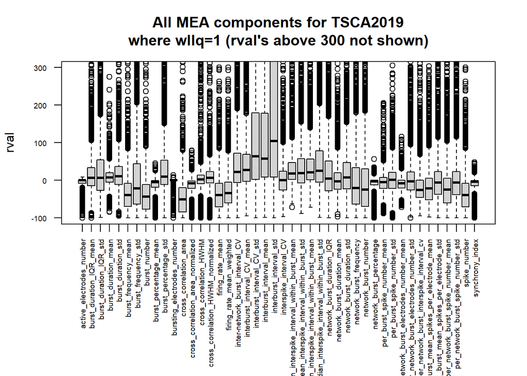

```r
# PLOTS to visually confirm results

# MEA points from -100 to 300
# by acnm
default_oma <- par("oma")
par(oma = c(default_oma[1]+5, default_oma[2:4]))
boxplot(rval ~ sub("CCTE_Shafer_MEA_acute_","",acnm), dat[wllq == 1 & !grepl("(AB)|(LDH)",acnm)], main = paste0("All MEA components for ",project_name,"\nwhere wllq=1 (rval's above 300 not shown)"),
        ylim = c(-100, 300), las = 2, cex.axis = 0.6, xlab = "")
```

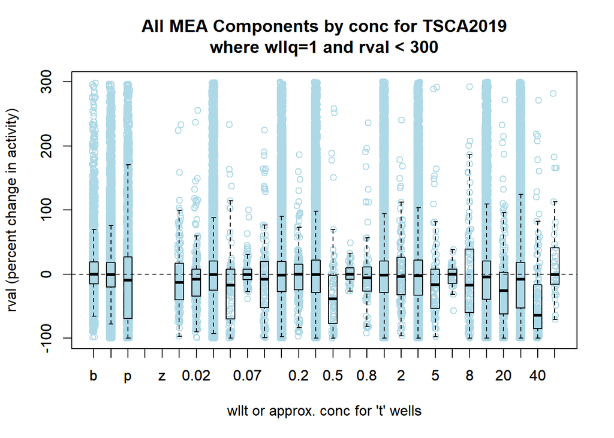

```r
par(oma = default_oma)

# by wllt/conc
dat[, wllt_conc := ifelse(wllt == "t", paste0(signif(conc,digits=1)), wllt)]
dat$wllt_conc <- factor(dat$wllt_conc,
                        levels = c(dat[wllt!="t",sort(unique(wllt))], paste0(dat[wllt=="t",sort(unique(signif(conc,digits=1)))])), ordered = T)
stripchart(rval ~ wllt_conc, dat[wllq == 1 & !grepl("(AB)|(LDH)",acnm) & rval < 300],
           vertical = T, pch = 1, method = "jitter", xlab = "wllt or approx. conc for 't' wells", ylab = "rval (percent change in activity)", col = "lightblue",
           main = paste0("All MEA Components by conc for ",project_name,"\nwhere wllq=1 and rval < 300"))
boxplot(rval ~ wllt_conc, dat[wllq == 1 & !grepl("(AB)|(LDH)",acnm) & rval < 300], outline = F, col = "transparent", boxwex = 0.5, add = T)
abline(h = 0, lty = "dashed")
```

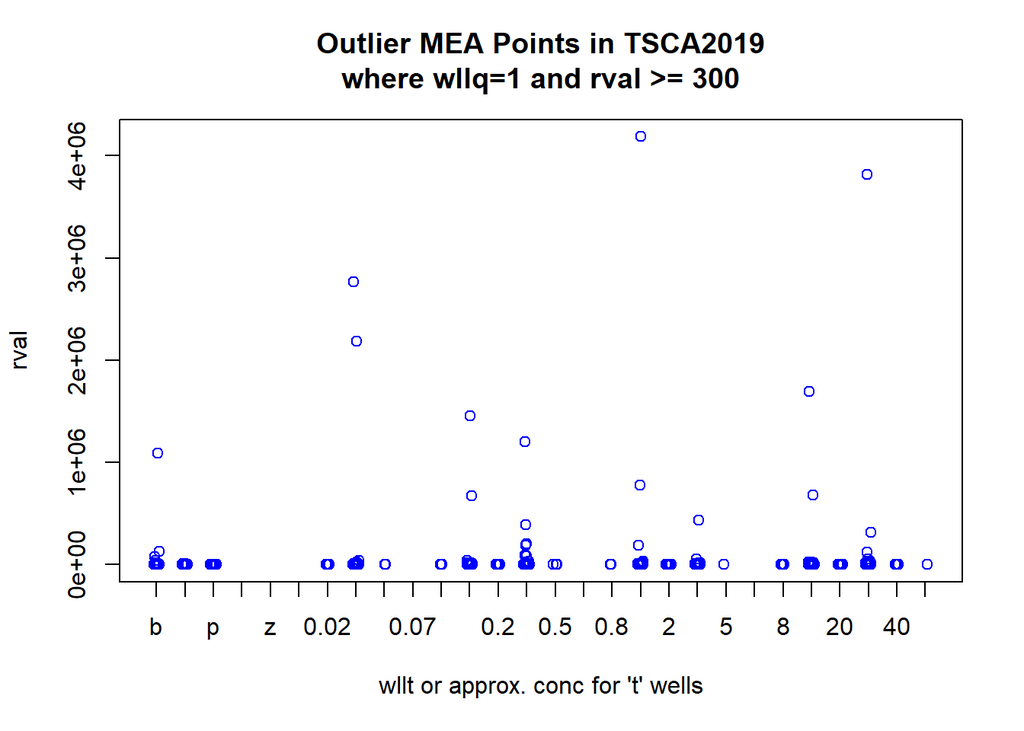

```r
# View the extent of extreme outliers (usually due to very small baseline value)
stripchart(rval ~ wllt_conc, dat[wllq == 1 & !grepl("(AB)|(LDH)",acnm) & rval >= 300],
           vertical = T, pch = 1, method = "jitter", xlab = "wllt or approx. conc for 't' wells", col = "blue",
           main = paste0("Outlier MEA Points in ",project_name,"\nwhere wllq=1 and rval >= 300"))
```

```r
cat("\nSummary of MEA rval's above 300% change by acnm (for wllt 't' or 'n'):\n")
```

```
##
## Summary of MEA rval's above 300% change by acnm (for wllt 't' or 'n'):
```

```r
print(dat[wllt %in% c("t","n") & wllq == 1 & !grepl("(AB)|(LDH)",acnm) & rval >= 300, .(wllts = paste0(sort(unique(wllt)),collapse=","), .N), by = c("acnm")][order(-N)])
```

```
##                                                                       acnm
##  1:                          CCTE_Shafer_MEA_acute_interburst_interval_std
##  2:                         CCTE_Shafer_MEA_acute_interburst_interval_mean
##  3:                       CCTE_Shafer_MEA_acute_interburst_interval_CV_std
##  4:                              CCTE_Shafer_MEA_acute_burst_frequency_std
##  5:                             CCTE_Shafer_MEA_acute_burst_percentage_std
##  6:      CCTE_Shafer_MEA_acute_median_interspike_interval_within_burst_std
##  7:                  CCTE_Shafer_MEA_acute_inter-network_burst_interval_CV
##  8:                           CCTE_Shafer_MEA_acute_burst_duration_IQR_std
##  9:                           CCTE_Shafer_MEA_acute_cross_correlation_HWHM
## 10:                       CCTE_Shafer_MEA_acute_network_burst_duration_IQR
## 11:                      CCTE_Shafer_MEA_acute_interburst_interval_CV_mean
## 12:          CCTE_Shafer_MEA_acute_per_network_burst_electrodes_number_std
## 13:                          CCTE_Shafer_MEA_acute_network_burst_frequency
## 14:                             CCTE_Shafer_MEA_acute_network_burst_number
```

[output cut: 57 more lines]

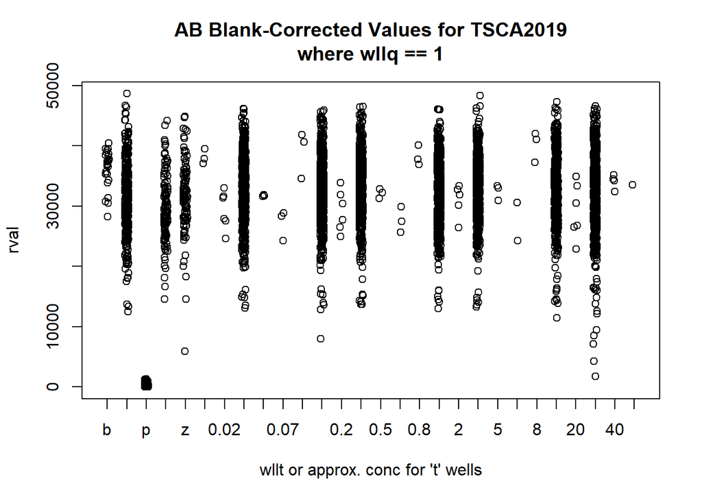

```r
# View Cytotox components
stripchart(rval ~ wllt_conc, dat[wllq == 1 & grepl("AB",acnm)],
           vertical = TRUE, pch = 1, method = "jitter", xlab = "wllt or approx. conc for 't' wells", main = paste0("AB Blank-Corrected Values for ",project_name,"\nwhere wllq == 1"))
```

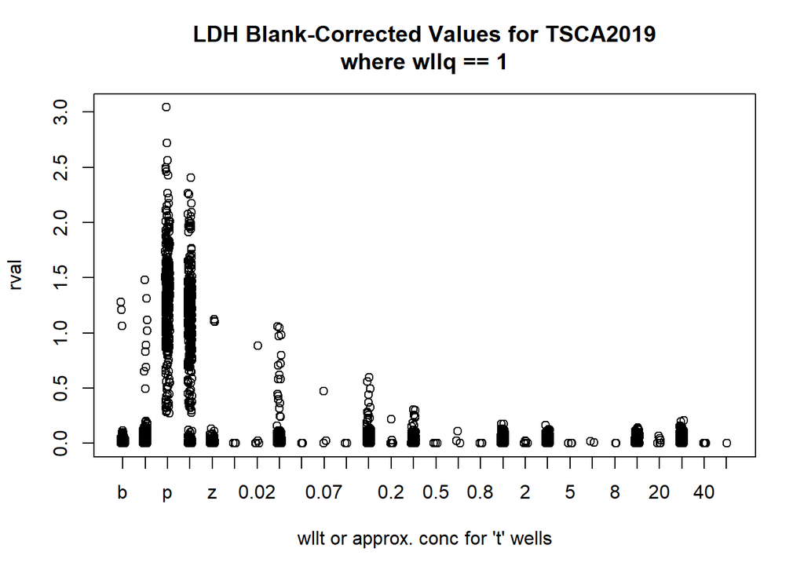

```r
stripchart(rval ~ wllt_conc, dat[wllq == 1 & grepl("LDH",acnm)],
           vertical = TRUE, pch = 1, method = "jitter", xlab = "wllt or approx. conc for 't' wells", main = paste0("LDH Blank-Corrected Values for ",project_name,"\nwhere wllq == 1"))
```

```r
dat[, wllt_conc := NULL]
```

# Save final table

```r
# Note that the cndx here is different than the cndx applied in tcpl
setnames(dat, old = 'cndx', new = 'cndx_pre_pro')

# Select columns to save
keep.columns <- c(

  # Columns needed for tcpl lvl0
  'acnm','apid', 'rowi', 'coli', 'conc','rval','srcf','spid','wllt','wllq',

  # Additional columns for our documentation
  'acsn',
  'treatment', 'treatment_srcf','spidmap_file',
  'cndx_pre_pro','conc_srcf', 'units',  'stock_conc', 'stock_conc_unit',
  'wllq_notes', 'wllq_ref',
  'experiment.date','culture.date','culture_folder','plate.id', # apid = experiment.date

  # MEA-acute specific columns
  'activity_value.b', #  activity value from baseline recording in well
  'activity_value.t', # activity value from treated recording in well
  'low_ae_flag.b','high_mfr_flag.b','low_mfr_flag.b' # flags added by add_wllq_by_recording, based on baseline activity
)
dat <- dat[, .SD, .SDcols = keep.columns]


# Save the file
setkey(dat, NULL) # remove keys to make the file smaller
# Optional character description of the file, modify as needed
acn.dat.description <- paste0(project_name,' MEA acn pre-processed data
Date prepared: ',as.character.Date(Sys.Date()),
'\nTo do before tcplWriteLvl0:
* Check that none of the data has been pipelined before (i.e., merge with current level 0 data and check for duplicates by apid, rowi, coli, and acnm)')
cat(acn.dat.description)
```

```
## TSCA2019 MEA acn pre-processed data
## Date prepared: 2023-08-02
## To do before tcplWriteLvl0:
## * Check that none of the data has been pipelined before (i.e., merge with current level 0 data and check for duplicates by apid, rowi, coli, and acnm)
```

```r
save(dat, acn.dat.description,
     file = file.path(project.output.dir, "output", paste0(project_name,"_MEA_Acute_for_tcpl_lvl0.RData")))
```

You made it!